# 5장 우리나라 인구 소멸 위기 지역 분석

### 작성 : [PinkWink](http://pinkwink.kr)

### 인구 소멸 위기 지역:

> ‘한국의 ‘지방소멸’에 관한 7가지 분석’ 보고서를 쓴 이상호 한국고용정보원 부연구위원의 분석 방법을 이용. 65세 이상 노인 인구와 20∼39세 여성 인구를 비교해 **젊은 여성 인구가 노인 인구의 절반에 미달할 경우 ‘소멸 위험 지역’으로 분류**하는 방식이다.

## 5-2. 인구 데이터 확보하고 정리하기

```python
import pandas as pd
import numpy as np

import platform
import matplotlib.pyplot as plt

%matplotlib inline

path = "c:/Windows/Fonts/malgun.ttf"
from matplotlib import font_manager, rc
if platform.system() == 'Darwin':
    rc('font', family='AppleGothic')
elif platform.system() == 'Windows':
    font_name = font_manager.FontProperties(fname=path).get_name()
    rc('font', family=font_name)
else:
    print('Unknown system... sorry~~~~')

plt.rcParams['axes.unicode_minus'] = False
```

```python
population = pd.read_excel('../data/05. population_raw_data.xlsx', header=1)
population.fillna(method='pad', inplace=True)

population.rename(columns = {'행정구역(동읍면)별(1)':'광역시도',
                             '행정구역(동읍면)별(2)':'시도',
                             '계':'인구수'}, inplace=True)

population = population[(population['시도'] != '소계')]

population
```

|  | 광역시도 | 시도 | 항목 | 인구수 | 20 - 24세 | 25 - 29세 | 30 - 34세 | 35 - 39세 | 65 - 69세 | 70 - 74세 | 75 - 79세 | 80 - 84세 | 85 - 89세 | 90 - 94세 | 95 - 99세 | 100+ |
| --- | --- | --- | --- | --- | --- | --- | --- | --- | --- | --- | --- | --- | --- | --- | --- | --- |
| 6 | 서울특별시 | 종로구 | 총인구수 (명) | 152737.0 | 11379.0 | 11891.0 | 10684 | 10379.0 | 7411.0 | 6636.0 | 5263 | 3104.0 | 1480.0 | 602.0 | 234 | 220.0 |
| 7 | 서울특별시 | 종로구 | 남자인구수 (명) | 75201.0 | 5620.0 | 6181.0 | 5387 | 5034.0 | 3411.0 | 3009.0 | 2311 | 1289.0 | 506.0 | 207.0 | 89 | 73.0 |
| 8 | 서울특별시 | 종로구 | 여자인구수 (명) | 77536.0 | 5759.0 | 5710.0 | 5297 | 5345.0 | 4000.0 | 3627.0 | 2952 | 1815.0 | 974.0 | 395.0 | 145 | 147.0 |
| 9 | 서울특별시 | 중구 | 총인구수 (명) | 125249.0 | 8216.0 | 9529.0 | 10332 | 10107.0 | 6399.0 | 5313.0 | 4127 | 2502.0 | 1260.0 | 469.0 | 158 | 160.0 |
| 10 | 서울특별시 | 중구 | 남자인구수 (명) | 62204.0 | 4142.0 | 4792.0 | 5192 | 5221.0 | 3113.0 | 2405.0 | 1752 | 929.0 | 414.0 | 132.0 | 56 | 51.0 |
| 11 | 서울특별시 | 중구 | 여자인구수 (명) | 63045.0 | 4074.0 | 4737.0 | 5140 | 4886.0 | 3286.0 | 2908.0 | 2375 | 1573.0 | 846.0 | 337.0 | 102 | 109.0 |
| 12 | 서울특별시 | 용산구 | 총인구수 (명) | 230241.0 | 14317.0 | 16972.0 | 19032 | 19127.0 | 10675.0 | 9093.0 | 7477 | 4553.0 | 2254.0 | 916.0 | 264 | 315.0 |
| 13 | 서울특별시 | 용산구 | 남자인구수 (명) | 111601.0 | 6937.0 | 8373.0 | 9455 | 9434.0 | 4834.0 | 3975.0 | 3094 | 1739.0 | 750.0 | 284.0 | 102 | 88.0 |
| 14 | 서울특별시 | 용산구 | 여자인구수 (명) | 118640.0 | 7380.0 | 8599.0 | 9577 | 9693.0 | 5841.0 | 5118.0 | 4383 | 2814.0 | 1504.0 | 632.0 | 162 | 227.0 |
| 15 | 서울특별시 | 성동구 | 총인구수 (명) | 299259.0 | 20813.0 | 23383.0 | 25507 | 25979.0 | 12938.0 | 10734.0 | 7989 | 4450.0 | 1944.0 | 678.0 | 209 | 198.0 |
| 16 | 서울특별시 | 성동구 | 남자인구수 (명) | 148326.0 | 10609.0 | 11848.0 | 12692 | 13154.0 | 6090.0 | 4863.0 | 3480 | 1698.0 | 580.0 | 184.0 | 56 | 54.0 |
| 17 | 서울특별시 | 성동구 | 여자인구수 (명) | 150933.0 | 10204.0 | 11535.0 | 12815 | 12825.0 | 6848.0 | 5871.0 | 4509 | 2752.0 | 1364.0 | 494.0 | 153 | 144.0 |
| 18 | 서울특별시 | 광진구 | 총인구수 (명) | 357215.0 | 27368.0 | 32092.0 | 32302 | 29496.0 | 14402.0 | 11300.0 | 8121 | 4349.0 | 2029.0 | 689.0 | 228 | 174.0 |
| 19 | 서울특별시 | 광진구 | 남자인구수 (명) | 174797.0 | 13317.0 | 15555.0 | 16034 | 14875.0 | 6775.0 | 5376.0 | 3693 | 1609.0 | 631.0 | 170.0 | 54 | 37.0 |
| 20 | 서울특별시 | 광진구 | 여자인구수 (명) | 182418.0 | 14051.0 | 16537.0 | 16268 | 14621.0 | 7627.0 | 5924.0 | 4428 | 2740.0 | 1398.0 | 519.0 | 174 | 137.0 |
| 21 | 서울특별시 | 동대문구 | 총인구수 (명) | 355069.0 | 26261.0 | 27808.0 | 27277 | 28095.0 | 17506.0 | 14867.0 | 11008 | 5926.0 | 2577.0 | 887.0 | 288 | 242.0 |
| 22 | 서울특별시 | 동대문구 | 남자인구수 (명) | 177640.0 | 13162.0 | 14859.0 | 14140 | 14489.0 | 8237.0 | 6815.0 | 4950 | 2375.0 | 801.0 | 248.0 | 87 | 68.0 |
| 23 | 서울특별시 | 동대문구 | 여자인구수 (명) | 177429.0 | 13099.0 | 12949.0 | 13137 | 13606.0 | 9269.0 | 8052.0 | 6058 | 3551.0 | 1776.0 | 639.0 | 201 | 174.0 |
| 24 | 서울특별시 | 중랑구 | 총인구수 (명) | 411005.0 | 28727.0 | 29833.0 | 32277 | 32632.0 | 19957.0 | 15415.0 | 10783 | 5784.0 | 2596.0 | 896.0 | 257 | 154.0 |
| 25 | 서울특별시 | 중랑구 | 남자인구수 (명) | 204900.0 | 14676.0 | 14784.0 | 16607 | 17248.0 | 9448.0 | 7189.0 | 4879 | 2214.0 | 667.0 | 211.0 | 57 | 37.0 |
| 26 | 서울특별시 | 중랑구 | 여자인구수 (명) | 206105.0 | 14051.0 | 15049.0 | 15670 | 15384.0 | 10509.0 | 8226.0 | 5904 | 3570.0 | 1929.0 | 685.0 | 200 | 117.0 |
| 27 | 서울특별시 | 성북구 | 총인구수 (명) | 450355.0 | 32372.0 | 32003.0 | 32154 | 35029.0 | 20618.0 | 17629.0 | 13312 | 7284.0 | 3279.0 | 1099.0 | 352 | 305.0 |
| 28 | 서울특별시 | 성북구 | 남자인구수 (명) | 219951.0 | 15761.0 | 16229.0 | 16075 | 17424.0 | 9402.0 | 7979.0 | 5825 | 2856.0 | 978.0 | 287.0 | 87 | 78.0 |
| 29 | 서울특별시 | 성북구 | 여자인구수 (명) | 230404.0 | 16611.0 | 15774.0 | 16079 | 17605.0 | 11216.0 | 9650.0 | 7487 | 4428.0 | 2301.0 | 812.0 | 265 | 227.0 |
| 30 | 서울특별시 | 강북구 | 총인구수 (명) | 327195.0 | 22058.0 | 21374.0 | 22650 | 24750.0 | 18172.0 | 15323.0 | 11103 | 5654.0 | 2373.0 | 842.0 | 256 | 241.0 |
| 31 | 서울특별시 | 강북구 | 남자인구수 (명) | 160861.0 | 11206.0 | 10737.0 | 11838 | 12998.0 | 8084.0 | 6836.0 | 4961 | 2313.0 | 731.0 | 219.0 | 66 | 63.0 |
| 32 | 서울특별시 | 강북구 | 여자인구수 (명) | 166334.0 | 10852.0 | 10637.0 | 10812 | 11752.0 | 10088.0 | 8487.0 | 6142 | 3341.0 | 1642.0 | 623.0 | 190 | 178.0 |
| 33 | 서울특별시 | 도봉구 | 총인구수 (명) | 348220.0 | 24350.0 | 22867.0 | 23613 | 25303.0 | 16819.0 | 13559.0 | 10265 | 5829.0 | 2696.0 | 938.0 | 231 | 129.0 |
| 34 | 서울특별시 | 도봉구 | 남자인구수 (명) | 171238.0 | 12666.0 | 11645.0 | 12255 | 12757.0 | 8073.0 | 6328.0 | 4547 | 2172.0 | 865.0 | 240.0 | 68 | 25.0 |
| 35 | 서울특별시 | 도봉구 | 여자인구수 (명) | 176982.0 | 11684.0 | 11222.0 | 11358 | 12546.0 | 8746.0 | 7231.0 | 5718 | 3657.0 | 1831.0 | 698.0 | 163 | 104.0 |
| ... | ... | ... | ... | ... | ... | ... | ... | ... | ... | ... | ... | ... | ... | ... | ... | ... |
| 813 | 경상남도 | 창녕군 | 총인구수 (명) | 63982.0 | 3279.0 | 2721.0 | 2863 | 3309.0 | 4498.0 | 3981.0 | 4202 | 2813.0 | 1261.0 | 321.0 | 54 | 19.0 |
| 814 | 경상남도 | 창녕군 | 남자인구수 (명) | 31735.0 | 1922.0 | 1591.0 | 1548 | 1820.0 | 2174.0 | 1639.0 | 1500 | 876.0 | 283.0 | 56.0 | 12 | 0.0 |
| 815 | 경상남도 | 창녕군 | 여자인구수 (명) | 32247.0 | 1357.0 | 1130.0 | 1315 | 1489.0 | 2324.0 | 2342.0 | 2702 | 1937.0 | 978.0 | 265.0 | 42 | 19.0 |
| 816 | 경상남도 | 고성군 | 총인구수 (명) | 54703.0 | 2672.0 | 1989.0 | 2582 | 3102.0 | 3828.0 | 3282.0 | 3268 | 2459.0 | 1179.0 | 363.0 | 66 | 17.0 |
| 817 | 경상남도 | 고성군 | 남자인구수 (명) | 27452.0 | 1538.0 | 1117.0 | 1442 | 1762.0 | 1880.0 | 1398.0 | 1222 | 804.0 | 282.0 | 63.0 | 13 | 3.0 |
| 818 | 경상남도 | 고성군 | 여자인구수 (명) | 27251.0 | 1134.0 | 872.0 | 1140 | 1340.0 | 1948.0 | 1884.0 | 2046 | 1655.0 | 897.0 | 300.0 | 53 | 14.0 |
| 819 | 경상남도 | 남해군 | 총인구수 (명) | 45129.0 | 2130.0 | 1454.0 | 1336 | 1727.0 | 3669.0 | 3356.0 | 3644 | 2816.0 | 1538.0 | 559.0 | 91 | 19.0 |
| 820 | 경상남도 | 남해군 | 남자인구수 (명) | 21566.0 | 1273.0 | 827.0 | 723 | 892.0 | 1753.0 | 1439.0 | 1358 | 874.0 | 361.0 | 88.0 | 12 | 0.0 |
| 821 | 경상남도 | 남해군 | 여자인구수 (명) | 23563.0 | 857.0 | 627.0 | 613 | 835.0 | 1916.0 | 1917.0 | 2286 | 1942.0 | 1177.0 | 471.0 | 79 | 19.0 |
| 822 | 경상남도 | 하동군 | 총인구수 (명) | 49622.0 | 2642.0 | 2006.0 | 1808 | 2118.0 | 3569.0 | 3239.0 | 3451 | 2464.0 | 1285.0 | 407.0 | 80 | 19.0 |
| 823 | 경상남도 | 하동군 | 남자인구수 (명) | 24463.0 | 1521.0 | 1152.0 | 975 | 1147.0 | 1698.0 | 1356.0 | 1266 | 765.0 | 337.0 | 81.0 | 18 | 2.0 |
| 824 | 경상남도 | 하동군 | 여자인구수 (명) | 25159.0 | 1121.0 | 854.0 | 833 | 971.0 | 1871.0 | 1883.0 | 2185 | 1699.0 | 948.0 | 326.0 | 62 | 17.0 |
| 825 | 경상남도 | 산청군 | 총인구수 (명) | 36098.0 | 1591.0 | 1249.0 | 1273 | 1448.0 | 2712.0 | 2652.0 | 2870 | 2059.0 | 953.0 | 314.0 | 63 | 15.0 |
| 826 | 경상남도 | 산청군 | 남자인구수 (명) | 17666.0 | 907.0 | 689.0 | 681 | 823.0 | 1370.0 | 1085.0 | 1031 | 642.0 | 249.0 | 69.0 | 10 | 2.0 |
| 827 | 경상남도 | 산청군 | 여자인구수 (명) | 18432.0 | 684.0 | 560.0 | 592 | 625.0 | 1342.0 | 1567.0 | 1839 | 1417.0 | 704.0 | 245.0 | 53 | 13.0 |
| 828 | 경상남도 | 함양군 | 총인구수 (명) | 40241.0 | 1943.0 | 1332.0 | 1453 | 1792.0 | 2869.0 | 2712.0 | 3124 | 2063.0 | 1050.0 | 360.0 | 64 | 32.0 |
| 829 | 경상남도 | 함양군 | 남자인구수 (명) | 19244.0 | 1077.0 | 717.0 | 765 | 939.0 | 1321.0 | 1041.0 | 1197 | 617.0 | 248.0 | 96.0 | 10 | 8.0 |
| 830 | 경상남도 | 함양군 | 여자인구수 (명) | 20997.0 | 866.0 | 615.0 | 688 | 853.0 | 1548.0 | 1671.0 | 1927 | 1446.0 | 802.0 | 264.0 | 54 | 24.0 |
| 831 | 경상남도 | 거창군 | 총인구수 (명) | 63308.0 | 3701.0 | 2478.0 | 2677 | 3277.0 | 3792.0 | 3493.0 | 3815 | 2682.0 | 1269.0 | 416.0 | 98 | 26.0 |
| 832 | 경상남도 | 거창군 | 남자인구수 (명) | 30746.0 | 2108.0 | 1399.0 | 1379 | 1638.0 | 1731.0 | 1394.0 | 1448 | 865.0 | 358.0 | 91.0 | 22 | 7.0 |
| 833 | 경상남도 | 거창군 | 여자인구수 (명) | 32562.0 | 1593.0 | 1079.0 | 1298 | 1639.0 | 2061.0 | 2099.0 | 2367 | 1817.0 | 911.0 | 325.0 | 76 | 19.0 |
| 834 | 경상남도 | 합천군 | 총인구수 (명) | 48026.0 | 2057.0 | 1540.0 | 1638 | 1943.0 | 3891.0 | 3717.0 | 4349 | 3142.0 | 1346.0 | 409.0 | 90 | 28.0 |
| 835 | 경상남도 | 합천군 | 남자인구수 (명) | 22825.0 | 1179.0 | 878.0 | 881 | 1060.0 | 1812.0 | 1484.0 | 1526 | 938.0 | 356.0 | 80.0 | 14 | 2.0 |
| 836 | 경상남도 | 합천군 | 여자인구수 (명) | 25201.0 | 878.0 | 662.0 | 757 | 883.0 | 2079.0 | 2233.0 | 2823 | 2204.0 | 990.0 | 329.0 | 76 | 26.0 |
| 840 | 제주특별자치도 | 제주시 | 총인구수 (명) | 470665.0 | 32638.0 | 25363.0 | 29771 | 36412.0 | 17739.0 | 14659.0 | 12119 | 8386.0 | 3976.0 | 1613.0 | 513 | 154.0 |
| 841 | 제주특별자치도 | 제주시 | 남자인구수 (명) | 235977.0 | 17377.0 | 13118.0 | 15084 | 18350.0 | 8474.0 | 6782.0 | 4941 | 2737.0 | 854.0 | 226.0 | 53 | 17.0 |
| 842 | 제주특별자치도 | 제주시 | 여자인구수 (명) | 234688.0 | 15261.0 | 12245.0 | 14687 | 18062.0 | 9265.0 | 7877.0 | 7178 | 5649.0 | 3122.0 | 1387.0 | 460 | 137.0 |
| 843 | 제주특별자치도 | 서귀포시 | 총인구수 (명) | 170932.0 | 10505.0 | 8067.0 | 9120 | 11606.0 | 8686.0 | 7460.0 | 6456 | 4521.0 | 1855.0 | 733.0 | 242 | 77.0 |
| 844 | 제주특별자치도 | 서귀포시 | 남자인구수 (명) | 86568.0 | 5600.0 | 4247.0 | 4693 | 6082.0 | 4237.0 | 3441.0 | 2611 | 1494.0 | 370.0 | 103.0 | 29 | 9.0 |
| 845 | 제주특별자치도 | 서귀포시 | 여자인구수 (명) | 84364.0 | 4905.0 | 3820.0 | 4427 | 5524.0 | 4449.0 | 4019.0 | 3845 | 3027.0 | 1485.0 | 630.0 | 213 | 68.0 |

792 rows × 16 columns

```python
population.is_copy = False

population.rename(columns = {'항목':'구분'}, inplace=True)

population.loc[population['구분'] == '총인구수 (명)', '구분'] = '합계'
population.loc[population['구분'] == '남자인구수 (명)', '구분'] = '남자'
population.loc[population['구분'] == '여자인구수 (명)', '구분'] = '여자'

population
```

|  | 광역시도 | 시도 | 구분 | 인구수 | 20 - 24세 | 25 - 29세 | 30 - 34세 | 35 - 39세 | 65 - 69세 | 70 - 74세 | 75 - 79세 | 80 - 84세 | 85 - 89세 | 90 - 94세 | 95 - 99세 | 100+ |
| --- | --- | --- | --- | --- | --- | --- | --- | --- | --- | --- | --- | --- | --- | --- | --- | --- |
| 6 | 서울특별시 | 종로구 | 합계 | 152737.0 | 11379.0 | 11891.0 | 10684 | 10379.0 | 7411.0 | 6636.0 | 5263 | 3104.0 | 1480.0 | 602.0 | 234 | 220.0 |
| 7 | 서울특별시 | 종로구 | 남자 | 75201.0 | 5620.0 | 6181.0 | 5387 | 5034.0 | 3411.0 | 3009.0 | 2311 | 1289.0 | 506.0 | 207.0 | 89 | 73.0 |
| 8 | 서울특별시 | 종로구 | 여자 | 77536.0 | 5759.0 | 5710.0 | 5297 | 5345.0 | 4000.0 | 3627.0 | 2952 | 1815.0 | 974.0 | 395.0 | 145 | 147.0 |
| 9 | 서울특별시 | 중구 | 합계 | 125249.0 | 8216.0 | 9529.0 | 10332 | 10107.0 | 6399.0 | 5313.0 | 4127 | 2502.0 | 1260.0 | 469.0 | 158 | 160.0 |
| 10 | 서울특별시 | 중구 | 남자 | 62204.0 | 4142.0 | 4792.0 | 5192 | 5221.0 | 3113.0 | 2405.0 | 1752 | 929.0 | 414.0 | 132.0 | 56 | 51.0 |
| 11 | 서울특별시 | 중구 | 여자 | 63045.0 | 4074.0 | 4737.0 | 5140 | 4886.0 | 3286.0 | 2908.0 | 2375 | 1573.0 | 846.0 | 337.0 | 102 | 109.0 |
| 12 | 서울특별시 | 용산구 | 합계 | 230241.0 | 14317.0 | 16972.0 | 19032 | 19127.0 | 10675.0 | 9093.0 | 7477 | 4553.0 | 2254.0 | 916.0 | 264 | 315.0 |
| 13 | 서울특별시 | 용산구 | 남자 | 111601.0 | 6937.0 | 8373.0 | 9455 | 9434.0 | 4834.0 | 3975.0 | 3094 | 1739.0 | 750.0 | 284.0 | 102 | 88.0 |
| 14 | 서울특별시 | 용산구 | 여자 | 118640.0 | 7380.0 | 8599.0 | 9577 | 9693.0 | 5841.0 | 5118.0 | 4383 | 2814.0 | 1504.0 | 632.0 | 162 | 227.0 |
| 15 | 서울특별시 | 성동구 | 합계 | 299259.0 | 20813.0 | 23383.0 | 25507 | 25979.0 | 12938.0 | 10734.0 | 7989 | 4450.0 | 1944.0 | 678.0 | 209 | 198.0 |
| 16 | 서울특별시 | 성동구 | 남자 | 148326.0 | 10609.0 | 11848.0 | 12692 | 13154.0 | 6090.0 | 4863.0 | 3480 | 1698.0 | 580.0 | 184.0 | 56 | 54.0 |
| 17 | 서울특별시 | 성동구 | 여자 | 150933.0 | 10204.0 | 11535.0 | 12815 | 12825.0 | 6848.0 | 5871.0 | 4509 | 2752.0 | 1364.0 | 494.0 | 153 | 144.0 |
| 18 | 서울특별시 | 광진구 | 합계 | 357215.0 | 27368.0 | 32092.0 | 32302 | 29496.0 | 14402.0 | 11300.0 | 8121 | 4349.0 | 2029.0 | 689.0 | 228 | 174.0 |
| 19 | 서울특별시 | 광진구 | 남자 | 174797.0 | 13317.0 | 15555.0 | 16034 | 14875.0 | 6775.0 | 5376.0 | 3693 | 1609.0 | 631.0 | 170.0 | 54 | 37.0 |
| 20 | 서울특별시 | 광진구 | 여자 | 182418.0 | 14051.0 | 16537.0 | 16268 | 14621.0 | 7627.0 | 5924.0 | 4428 | 2740.0 | 1398.0 | 519.0 | 174 | 137.0 |
| 21 | 서울특별시 | 동대문구 | 합계 | 355069.0 | 26261.0 | 27808.0 | 27277 | 28095.0 | 17506.0 | 14867.0 | 11008 | 5926.0 | 2577.0 | 887.0 | 288 | 242.0 |
| 22 | 서울특별시 | 동대문구 | 남자 | 177640.0 | 13162.0 | 14859.0 | 14140 | 14489.0 | 8237.0 | 6815.0 | 4950 | 2375.0 | 801.0 | 248.0 | 87 | 68.0 |
| 23 | 서울특별시 | 동대문구 | 여자 | 177429.0 | 13099.0 | 12949.0 | 13137 | 13606.0 | 9269.0 | 8052.0 | 6058 | 3551.0 | 1776.0 | 639.0 | 201 | 174.0 |
| 24 | 서울특별시 | 중랑구 | 합계 | 411005.0 | 28727.0 | 29833.0 | 32277 | 32632.0 | 19957.0 | 15415.0 | 10783 | 5784.0 | 2596.0 | 896.0 | 257 | 154.0 |
| 25 | 서울특별시 | 중랑구 | 남자 | 204900.0 | 14676.0 | 14784.0 | 16607 | 17248.0 | 9448.0 | 7189.0 | 4879 | 2214.0 | 667.0 | 211.0 | 57 | 37.0 |
| 26 | 서울특별시 | 중랑구 | 여자 | 206105.0 | 14051.0 | 15049.0 | 15670 | 15384.0 | 10509.0 | 8226.0 | 5904 | 3570.0 | 1929.0 | 685.0 | 200 | 117.0 |
| 27 | 서울특별시 | 성북구 | 합계 | 450355.0 | 32372.0 | 32003.0 | 32154 | 35029.0 | 20618.0 | 17629.0 | 13312 | 7284.0 | 3279.0 | 1099.0 | 352 | 305.0 |
| 28 | 서울특별시 | 성북구 | 남자 | 219951.0 | 15761.0 | 16229.0 | 16075 | 17424.0 | 9402.0 | 7979.0 | 5825 | 2856.0 | 978.0 | 287.0 | 87 | 78.0 |
| 29 | 서울특별시 | 성북구 | 여자 | 230404.0 | 16611.0 | 15774.0 | 16079 | 17605.0 | 11216.0 | 9650.0 | 7487 | 4428.0 | 2301.0 | 812.0 | 265 | 227.0 |
| 30 | 서울특별시 | 강북구 | 합계 | 327195.0 | 22058.0 | 21374.0 | 22650 | 24750.0 | 18172.0 | 15323.0 | 11103 | 5654.0 | 2373.0 | 842.0 | 256 | 241.0 |
| 31 | 서울특별시 | 강북구 | 남자 | 160861.0 | 11206.0 | 10737.0 | 11838 | 12998.0 | 8084.0 | 6836.0 | 4961 | 2313.0 | 731.0 | 219.0 | 66 | 63.0 |
| 32 | 서울특별시 | 강북구 | 여자 | 166334.0 | 10852.0 | 10637.0 | 10812 | 11752.0 | 10088.0 | 8487.0 | 6142 | 3341.0 | 1642.0 | 623.0 | 190 | 178.0 |
| 33 | 서울특별시 | 도봉구 | 합계 | 348220.0 | 24350.0 | 22867.0 | 23613 | 25303.0 | 16819.0 | 13559.0 | 10265 | 5829.0 | 2696.0 | 938.0 | 231 | 129.0 |
| 34 | 서울특별시 | 도봉구 | 남자 | 171238.0 | 12666.0 | 11645.0 | 12255 | 12757.0 | 8073.0 | 6328.0 | 4547 | 2172.0 | 865.0 | 240.0 | 68 | 25.0 |
| 35 | 서울특별시 | 도봉구 | 여자 | 176982.0 | 11684.0 | 11222.0 | 11358 | 12546.0 | 8746.0 | 7231.0 | 5718 | 3657.0 | 1831.0 | 698.0 | 163 | 104.0 |
| ... | ... | ... | ... | ... | ... | ... | ... | ... | ... | ... | ... | ... | ... | ... | ... | ... |
| 813 | 경상남도 | 창녕군 | 합계 | 63982.0 | 3279.0 | 2721.0 | 2863 | 3309.0 | 4498.0 | 3981.0 | 4202 | 2813.0 | 1261.0 | 321.0 | 54 | 19.0 |
| 814 | 경상남도 | 창녕군 | 남자 | 31735.0 | 1922.0 | 1591.0 | 1548 | 1820.0 | 2174.0 | 1639.0 | 1500 | 876.0 | 283.0 | 56.0 | 12 | 0.0 |
| 815 | 경상남도 | 창녕군 | 여자 | 32247.0 | 1357.0 | 1130.0 | 1315 | 1489.0 | 2324.0 | 2342.0 | 2702 | 1937.0 | 978.0 | 265.0 | 42 | 19.0 |
| 816 | 경상남도 | 고성군 | 합계 | 54703.0 | 2672.0 | 1989.0 | 2582 | 3102.0 | 3828.0 | 3282.0 | 3268 | 2459.0 | 1179.0 | 363.0 | 66 | 17.0 |
| 817 | 경상남도 | 고성군 | 남자 | 27452.0 | 1538.0 | 1117.0 | 1442 | 1762.0 | 1880.0 | 1398.0 | 1222 | 804.0 | 282.0 | 63.0 | 13 | 3.0 |
| 818 | 경상남도 | 고성군 | 여자 | 27251.0 | 1134.0 | 872.0 | 1140 | 1340.0 | 1948.0 | 1884.0 | 2046 | 1655.0 | 897.0 | 300.0 | 53 | 14.0 |
| 819 | 경상남도 | 남해군 | 합계 | 45129.0 | 2130.0 | 1454.0 | 1336 | 1727.0 | 3669.0 | 3356.0 | 3644 | 2816.0 | 1538.0 | 559.0 | 91 | 19.0 |
| 820 | 경상남도 | 남해군 | 남자 | 21566.0 | 1273.0 | 827.0 | 723 | 892.0 | 1753.0 | 1439.0 | 1358 | 874.0 | 361.0 | 88.0 | 12 | 0.0 |
| 821 | 경상남도 | 남해군 | 여자 | 23563.0 | 857.0 | 627.0 | 613 | 835.0 | 1916.0 | 1917.0 | 2286 | 1942.0 | 1177.0 | 471.0 | 79 | 19.0 |
| 822 | 경상남도 | 하동군 | 합계 | 49622.0 | 2642.0 | 2006.0 | 1808 | 2118.0 | 3569.0 | 3239.0 | 3451 | 2464.0 | 1285.0 | 407.0 | 80 | 19.0 |
| 823 | 경상남도 | 하동군 | 남자 | 24463.0 | 1521.0 | 1152.0 | 975 | 1147.0 | 1698.0 | 1356.0 | 1266 | 765.0 | 337.0 | 81.0 | 18 | 2.0 |
| 824 | 경상남도 | 하동군 | 여자 | 25159.0 | 1121.0 | 854.0 | 833 | 971.0 | 1871.0 | 1883.0 | 2185 | 1699.0 | 948.0 | 326.0 | 62 | 17.0 |
| 825 | 경상남도 | 산청군 | 합계 | 36098.0 | 1591.0 | 1249.0 | 1273 | 1448.0 | 2712.0 | 2652.0 | 2870 | 2059.0 | 953.0 | 314.0 | 63 | 15.0 |
| 826 | 경상남도 | 산청군 | 남자 | 17666.0 | 907.0 | 689.0 | 681 | 823.0 | 1370.0 | 1085.0 | 1031 | 642.0 | 249.0 | 69.0 | 10 | 2.0 |
| 827 | 경상남도 | 산청군 | 여자 | 18432.0 | 684.0 | 560.0 | 592 | 625.0 | 1342.0 | 1567.0 | 1839 | 1417.0 | 704.0 | 245.0 | 53 | 13.0 |
| 828 | 경상남도 | 함양군 | 합계 | 40241.0 | 1943.0 | 1332.0 | 1453 | 1792.0 | 2869.0 | 2712.0 | 3124 | 2063.0 | 1050.0 | 360.0 | 64 | 32.0 |
| 829 | 경상남도 | 함양군 | 남자 | 19244.0 | 1077.0 | 717.0 | 765 | 939.0 | 1321.0 | 1041.0 | 1197 | 617.0 | 248.0 | 96.0 | 10 | 8.0 |
| 830 | 경상남도 | 함양군 | 여자 | 20997.0 | 866.0 | 615.0 | 688 | 853.0 | 1548.0 | 1671.0 | 1927 | 1446.0 | 802.0 | 264.0 | 54 | 24.0 |
| 831 | 경상남도 | 거창군 | 합계 | 63308.0 | 3701.0 | 2478.0 | 2677 | 3277.0 | 3792.0 | 3493.0 | 3815 | 2682.0 | 1269.0 | 416.0 | 98 | 26.0 |
| 832 | 경상남도 | 거창군 | 남자 | 30746.0 | 2108.0 | 1399.0 | 1379 | 1638.0 | 1731.0 | 1394.0 | 1448 | 865.0 | 358.0 | 91.0 | 22 | 7.0 |
| 833 | 경상남도 | 거창군 | 여자 | 32562.0 | 1593.0 | 1079.0 | 1298 | 1639.0 | 2061.0 | 2099.0 | 2367 | 1817.0 | 911.0 | 325.0 | 76 | 19.0 |
| 834 | 경상남도 | 합천군 | 합계 | 48026.0 | 2057.0 | 1540.0 | 1638 | 1943.0 | 3891.0 | 3717.0 | 4349 | 3142.0 | 1346.0 | 409.0 | 90 | 28.0 |
| 835 | 경상남도 | 합천군 | 남자 | 22825.0 | 1179.0 | 878.0 | 881 | 1060.0 | 1812.0 | 1484.0 | 1526 | 938.0 | 356.0 | 80.0 | 14 | 2.0 |
| 836 | 경상남도 | 합천군 | 여자 | 25201.0 | 878.0 | 662.0 | 757 | 883.0 | 2079.0 | 2233.0 | 2823 | 2204.0 | 990.0 | 329.0 | 76 | 26.0 |
| 840 | 제주특별자치도 | 제주시 | 합계 | 470665.0 | 32638.0 | 25363.0 | 29771 | 36412.0 | 17739.0 | 14659.0 | 12119 | 8386.0 | 3976.0 | 1613.0 | 513 | 154.0 |
| 841 | 제주특별자치도 | 제주시 | 남자 | 235977.0 | 17377.0 | 13118.0 | 15084 | 18350.0 | 8474.0 | 6782.0 | 4941 | 2737.0 | 854.0 | 226.0 | 53 | 17.0 |
| 842 | 제주특별자치도 | 제주시 | 여자 | 234688.0 | 15261.0 | 12245.0 | 14687 | 18062.0 | 9265.0 | 7877.0 | 7178 | 5649.0 | 3122.0 | 1387.0 | 460 | 137.0 |
| 843 | 제주특별자치도 | 서귀포시 | 합계 | 170932.0 | 10505.0 | 8067.0 | 9120 | 11606.0 | 8686.0 | 7460.0 | 6456 | 4521.0 | 1855.0 | 733.0 | 242 | 77.0 |
| 844 | 제주특별자치도 | 서귀포시 | 남자 | 86568.0 | 5600.0 | 4247.0 | 4693 | 6082.0 | 4237.0 | 3441.0 | 2611 | 1494.0 | 370.0 | 103.0 | 29 | 9.0 |
| 845 | 제주특별자치도 | 서귀포시 | 여자 | 84364.0 | 4905.0 | 3820.0 | 4427 | 5524.0 | 4449.0 | 4019.0 | 3845 | 3027.0 | 1485.0 | 630.0 | 213 | 68.0 |

792 rows × 16 columns

## 5-3. 인구 소멸 위기 지역 계산하고 데이터 정리하기

```python
population['20-39세'] = population['20 - 24세'] + population['25 - 29세'] + \
                        population['30 - 34세'] + population['35 - 39세']

population['65세이상'] = population['65 - 69세'] + population['70 - 74세'] + \
                        population['75 - 79세'] + population['80 - 84세'] + \
                        population['85 - 89세'] + population['90 - 94세'] + \
                        population['95 - 99세'] + population['100+']

population.head(10)
```

|  | 광역시도 | 시도 | 구분 | 인구수 | 20 - 24세 | 25 - 29세 | 30 - 34세 | 35 - 39세 | 65 - 69세 | 70 - 74세 | 75 - 79세 | 80 - 84세 | 85 - 89세 | 90 - 94세 | 95 - 99세 | 100+ | 20-39세 | 65세이상 |
| --- | --- | --- | --- | --- | --- | --- | --- | --- | --- | --- | --- | --- | --- | --- | --- | --- | --- | --- |
| 6 | 서울특별시 | 종로구 | 합계 | 152737.0 | 11379.0 | 11891.0 | 10684 | 10379.0 | 7411.0 | 6636.0 | 5263 | 3104.0 | 1480.0 | 602.0 | 234 | 220.0 | 44333.0 | 24950.0 |
| 7 | 서울특별시 | 종로구 | 남자 | 75201.0 | 5620.0 | 6181.0 | 5387 | 5034.0 | 3411.0 | 3009.0 | 2311 | 1289.0 | 506.0 | 207.0 | 89 | 73.0 | 22222.0 | 10895.0 |
| 8 | 서울특별시 | 종로구 | 여자 | 77536.0 | 5759.0 | 5710.0 | 5297 | 5345.0 | 4000.0 | 3627.0 | 2952 | 1815.0 | 974.0 | 395.0 | 145 | 147.0 | 22111.0 | 14055.0 |
| 9 | 서울특별시 | 중구 | 합계 | 125249.0 | 8216.0 | 9529.0 | 10332 | 10107.0 | 6399.0 | 5313.0 | 4127 | 2502.0 | 1260.0 | 469.0 | 158 | 160.0 | 38184.0 | 20388.0 |
| 10 | 서울특별시 | 중구 | 남자 | 62204.0 | 4142.0 | 4792.0 | 5192 | 5221.0 | 3113.0 | 2405.0 | 1752 | 929.0 | 414.0 | 132.0 | 56 | 51.0 | 19347.0 | 8852.0 |
| 11 | 서울특별시 | 중구 | 여자 | 63045.0 | 4074.0 | 4737.0 | 5140 | 4886.0 | 3286.0 | 2908.0 | 2375 | 1573.0 | 846.0 | 337.0 | 102 | 109.0 | 18837.0 | 11536.0 |
| 12 | 서울특별시 | 용산구 | 합계 | 230241.0 | 14317.0 | 16972.0 | 19032 | 19127.0 | 10675.0 | 9093.0 | 7477 | 4553.0 | 2254.0 | 916.0 | 264 | 315.0 | 69448.0 | 35547.0 |
| 13 | 서울특별시 | 용산구 | 남자 | 111601.0 | 6937.0 | 8373.0 | 9455 | 9434.0 | 4834.0 | 3975.0 | 3094 | 1739.0 | 750.0 | 284.0 | 102 | 88.0 | 34199.0 | 14866.0 |
| 14 | 서울특별시 | 용산구 | 여자 | 118640.0 | 7380.0 | 8599.0 | 9577 | 9693.0 | 5841.0 | 5118.0 | 4383 | 2814.0 | 1504.0 | 632.0 | 162 | 227.0 | 35249.0 | 20681.0 |
| 15 | 서울특별시 | 성동구 | 합계 | 299259.0 | 20813.0 | 23383.0 | 25507 | 25979.0 | 12938.0 | 10734.0 | 7989 | 4450.0 | 1944.0 | 678.0 | 209 | 198.0 | 95682.0 | 39140.0 |

- **pivot_table**을 이용하여 **광역시도, 시도**를 index로 두고, **구분**으로 세로를 첫 번째 컬럼을 잡고, value에 **인구수, 20~39세, 65세이상**으로 정리해 둔다.

```python
pop = pd.pivot_table(population,
                     index = ['광역시도', '시도'],
                     columns = ['구분'],
                     values = ['인구수', '20-39세', '65세이상'])
pop
```

| 광역시도 | 구분 시도 | 20-39세 남자 | 20-39세 여자 | 20-39세 합계 | 65세이상 남자 | 65세이상 여자 | 65세이상 합계 | 인구수 남자 | 인구수 여자 | 인구수 합계 |
| --- | --- | --- | --- | --- | --- | --- | --- | --- | --- | --- |
| 강원도 | 강릉시 | 26286.0 | 23098.0 | 49384.0 | 15767.0 | 21912.0 | 37679.0 | 106231.0 | 107615.0 | 213846.0 |
|  | 고성군 | 4494.0 | 2529.0 | 7023.0 | 2900.0 | 4251.0 | 7151.0 | 15899.0 | 14215.0 | 30114.0 |
|  | 동해시 | 11511.0 | 9753.0 | 21264.0 | 6392.0 | 8732.0 | 15124.0 | 47166.0 | 46131.0 | 93297.0 |
|  | 삼척시 | 8708.0 | 7115.0 | 15823.0 | 5892.0 | 8718.0 | 14610.0 | 35253.0 | 34346.0 | 69599.0 |
|  | 속초시 | 9956.0 | 8752.0 | 18708.0 | 5139.0 | 7613.0 | 12752.0 | 40288.0 | 41505.0 | 81793.0 |
|  | 양구군 | 4368.0 | 2481.0 | 6849.0 | 1650.0 | 2458.0 | 4108.0 | 12918.0 | 11092.0 | 24010.0 |
|  | 양양군 | 2916.0 | 2171.0 | 5087.0 | 2988.0 | 3993.0 | 6981.0 | 13838.0 | 13380.0 | 27218.0 |
|  | 영월군 | 4025.0 | 3134.0 | 7159.0 | 4215.0 | 5700.0 | 9915.0 | 20652.0 | 19421.0 | 40073.0 |
|  | 원주시 | 45755.0 | 43164.0 | 88919.0 | 17384.0 | 24862.0 | 42246.0 | 167854.0 | 170125.0 | 337979.0 |
|  | 인제군 | 5512.0 | 3449.0 | 8961.0 | 2413.0 | 3189.0 | 5602.0 | 17677.0 | 15043.0 | 32720.0 |
|  | 정선군 | 4138.0 | 3297.0 | 7435.0 | 3831.0 | 5177.0 | 9008.0 | 19975.0 | 18743.0 | 38718.0 |
|  | 철원군 | 7918.0 | 4714.0 | 12632.0 | 3804.0 | 5308.0 | 9112.0 | 25429.0 | 22584.0 | 48013.0 |
|  | 춘천시 | 37173.0 | 35422.0 | 72595.0 | 17259.0 | 24440.0 | 41699.0 | 138251.0 | 142456.0 | 280707.0 |
|  | 태백시 | 5333.0 | 4643.0 | 9976.0 | 3978.0 | 5288.0 | 9266.0 | 23899.0 | 23171.0 | 47070.0 |
|  | 평창군 | 4377.0 | 3585.0 | 7962.0 | 4223.0 | 5614.0 | 9837.0 | 22126.0 | 21192.0 | 43318.0 |
|  | 홍천군 | 7900.0 | 6258.0 | 14158.0 | 6450.0 | 8483.0 | 14933.0 | 35738.0 | 34338.0 | 70076.0 |
|  | 화천군 | 5397.0 | 2643.0 | 8040.0 | 1991.0 | 2815.0 | 4806.0 | 14554.0 | 11710.0 | 26264.0 |
|  | 횡성군 | 4512.0 | 3789.0 | 8301.0 | 4941.0 | 6382.0 | 11323.0 | 23398.0 | 22593.0 | 45991.0 |
| 경기도 | 가평군 | 7024.0 | 5771.0 | 12795.0 | 5960.0 | 7609.0 | 13569.0 | 31981.0 | 30467.0 | 62448.0 |
|  | 고양시 | 143723.0 | 145020.0 | 288743.0 | 46866.0 | 67226.0 | 114092.0 | 510923.0 | 528761.0 | 1039684.0 |
|  | 과천시 | 8582.0 | 8315.0 | 16897.0 | 3117.0 | 4618.0 | 7735.0 | 31013.0 | 32765.0 | 63778.0 |
|  | 광명시 | 49509.0 | 47807.0 | 97316.0 | 15468.0 | 21081.0 | 36549.0 | 168241.0 | 171243.0 | 339484.0 |
|  | 광주시 | 49690.0 | 45073.0 | 94763.0 | 16061.0 | 19142.0 | 35203.0 | 168345.0 | 159378.0 | 327723.0 |
|  | 구리시 | 27732.0 | 26941.0 | 54673.0 | 8903.0 | 11720.0 | 20623.0 | 96397.0 | 97366.0 | 193763.0 |
|  | 군포시 | 43183.0 | 41049.0 | 84232.0 | 12126.0 | 16404.0 | 28530.0 | 141647.0 | 143243.0 | 284890.0 |
|  | 권선구 | 60291.0 | 56279.0 | 116570.0 | 13234.0 | 17690.0 | 30924.0 | 180766.0 | 177627.0 | 358393.0 |
|  | 기흥구 | 56866.0 | 58658.0 | 115524.0 | 18831.0 | 24001.0 | 42832.0 | 206316.0 | 210847.0 | 417163.0 |
|  | 김포시 | 49921.0 | 49660.0 | 99581.0 | 17847.0 | 22658.0 | 40505.0 | 182597.0 | 180846.0 | 363443.0 |
|  | 남양주시 | 87416.0 | 86835.0 | 174251.0 | 33150.0 | 42836.0 | 75986.0 | 330749.0 | 331405.0 | 662154.0 |
|  | 단원구 | 49620.0 | 43619.0 | 93239.0 | 10430.0 | 14100.0 | 24530.0 | 161915.0 | 152087.0 | 314002.0 |
| ... | ... | ... | ... | ... | ... | ... | ... | ... | ... | ... |
| 충청남도 | 금산군 | 5448.0 | 4454.0 | 9902.0 | 6012.0 | 8594.0 | 14606.0 | 27558.0 | 27054.0 | 54612.0 |
|  | 논산시 | 14111.0 | 11900.0 | 26011.0 | 11593.0 | 16464.0 | 28057.0 | 61724.0 | 61489.0 | 123213.0 |
|  | 당진시 | 24970.0 | 19356.0 | 44326.0 | 11765.0 | 15680.0 | 27445.0 | 87388.0 | 79242.0 | 166630.0 |
|  | 동남구 | 38023.0 | 35222.0 | 73245.0 | 12858.0 | 17329.0 | 30187.0 | 131135.0 | 127784.0 | 258919.0 |
|  | 보령시 | 12314.0 | 9590.0 | 21904.0 | 9579.0 | 13389.0 | 22968.0 | 52521.0 | 51352.0 | 103873.0 |
|  | 부여군 | 6822.0 | 5348.0 | 12170.0 | 8575.0 | 12197.0 | 20772.0 | 34837.0 | 35350.0 | 70187.0 |
|  | 서북구 | 63523.0 | 57966.0 | 121489.0 | 11150.0 | 15664.0 | 26814.0 | 182987.0 | 176049.0 | 359036.0 |
|  | 서산시 | 23700.0 | 19196.0 | 42896.0 | 11840.0 | 16190.0 | 28030.0 | 87770.0 | 83018.0 | 170788.0 |
|  | 서천군 | 5219.0 | 4142.0 | 9361.0 | 7221.0 | 10363.0 | 17584.0 | 27539.0 | 28473.0 | 56012.0 |
|  | 아산시 | 47643.0 | 42296.0 | 89939.0 | 14581.0 | 20486.0 | 35067.0 | 155692.0 | 147237.0 | 302929.0 |
|  | 예산군 | 8450.0 | 6665.0 | 15115.0 | 9230.0 | 12776.0 | 22006.0 | 40827.0 | 40512.0 | 81339.0 |
|  | 천안시 | 101546.0 | 93188.0 | 194734.0 | 24008.0 | 32993.0 | 57001.0 | 314122.0 | 303833.0 | 617955.0 |
|  | 청양군 | 3207.0 | 2410.0 | 5617.0 | 4300.0 | 6029.0 | 10329.0 | 16389.0 | 16364.0 | 32753.0 |
|  | 태안군 | 6956.0 | 5271.0 | 12227.0 | 7241.0 | 9627.0 | 16868.0 | 32260.0 | 31640.0 | 63900.0 |
|  | 홍성군 | 11691.0 | 10428.0 | 22119.0 | 8889.0 | 12426.0 | 21315.0 | 49769.0 | 50202.0 | 99971.0 |
| 충청북도 | 괴산군 | 3606.0 | 2726.0 | 6332.0 | 4890.0 | 6702.0 | 11592.0 | 19773.0 | 19200.0 | 38973.0 |
|  | 단양군 | 2907.0 | 2289.0 | 5196.0 | 3278.0 | 4619.0 | 7897.0 | 15362.0 | 15141.0 | 30503.0 |
|  | 보은군 | 3097.0 | 2498.0 | 5595.0 | 4165.0 | 6022.0 | 10187.0 | 17093.0 | 17128.0 | 34221.0 |
|  | 상당구 | 23359.0 | 21071.0 | 44430.0 | 9727.0 | 13849.0 | 23576.0 | 86804.0 | 86897.0 | 173701.0 |
|  | 서원구 | 31810.0 | 29168.0 | 60978.0 | 9950.0 | 14237.0 | 24187.0 | 107866.0 | 109254.0 | 217120.0 |
|  | 영동군 | 5369.0 | 4217.0 | 9586.0 | 5564.0 | 8186.0 | 13750.0 | 25248.0 | 25304.0 | 50552.0 |
|  | 옥천군 | 5373.0 | 4445.0 | 9818.0 | 5533.0 | 7722.0 | 13255.0 | 26251.0 | 26016.0 | 52267.0 |
|  | 음성군 | 12684.0 | 10179.0 | 22863.0 | 7301.0 | 9605.0 | 16906.0 | 51372.0 | 46415.0 | 97787.0 |
|  | 제천시 | 16563.0 | 14279.0 | 30842.0 | 10227.0 | 13904.0 | 24131.0 | 68444.0 | 68073.0 | 136517.0 |
|  | 증평군 | 5531.0 | 4554.0 | 10085.0 | 2206.0 | 3117.0 | 5323.0 | 19110.0 | 18198.0 | 37308.0 |
|  | 진천군 | 9391.0 | 7622.0 | 17013.0 | 4731.0 | 6575.0 | 11306.0 | 36387.0 | 33563.0 | 69950.0 |
|  | 청원구 | 32216.0 | 27805.0 | 60021.0 | 8417.0 | 11914.0 | 20331.0 | 97006.0 | 93807.0 | 190813.0 |
|  | 청주시 | 128318.0 | 115719.0 | 244037.0 | 37882.0 | 53671.0 | 91553.0 | 419323.0 | 415874.0 | 835197.0 |
|  | 충주시 | 26600.0 | 22757.0 | 49357.0 | 14407.0 | 20383.0 | 34790.0 | 104877.0 | 103473.0 | 208350.0 |
|  | 흥덕구 | 40933.0 | 37675.0 | 78608.0 | 9788.0 | 13671.0 | 23459.0 | 127647.0 | 125916.0 | 253563.0 |

264 rows × 9 columns

- **소멸비율**이라는 컬럼에 인구소멸위기지역을 계산하기 위한 식을 적용한다
- 이 비율이 1보다 작으면 **인구소멸위기지역**으로 볼 수 있다.

```python
pop['소멸비율'] = pop['20-39세','여자'] / (pop['65세이상','합계'] / 2)
pop.head()
```

| 광역시도 | 구분 시도 | 20-39세 남자 | 20-39세 여자 | 20-39세 합계 | 65세이상 남자 | 65세이상 여자 | 65세이상 합계 | 인구수 남자 | 인구수 여자 | 인구수 합계 | 소멸비율 |
| --- | --- | --- | --- | --- | --- | --- | --- | --- | --- | --- | --- |
| 강원도 | 강릉시 | 26286.0 | 23098.0 | 49384.0 | 15767.0 | 21912.0 | 37679.0 | 106231.0 | 107615.0 | 213846.0 | 1.226041 |
|  | 고성군 | 4494.0 | 2529.0 | 7023.0 | 2900.0 | 4251.0 | 7151.0 | 15899.0 | 14215.0 | 30114.0 | 0.707314 |
|  | 동해시 | 11511.0 | 9753.0 | 21264.0 | 6392.0 | 8732.0 | 15124.0 | 47166.0 | 46131.0 | 93297.0 | 1.289738 |
|  | 삼척시 | 8708.0 | 7115.0 | 15823.0 | 5892.0 | 8718.0 | 14610.0 | 35253.0 | 34346.0 | 69599.0 | 0.973990 |
|  | 속초시 | 9956.0 | 8752.0 | 18708.0 | 5139.0 | 7613.0 | 12752.0 | 40288.0 | 41505.0 | 81793.0 | 1.372647 |

- 소멸위기지역인지를 boolean으로 지정해 둔다

```python
pop['소멸위기지역'] = pop['소멸비율'] < 1.0
pop.head()
```

| 광역시도 | 구분 시도 | 20-39세 남자 | 20-39세 여자 | 20-39세 합계 | 65세이상 남자 | 65세이상 여자 | 65세이상 합계 | 인구수 남자 | 인구수 여자 | 인구수 합계 | 소멸비율 | 소멸위기지역 |
| --- | --- | --- | --- | --- | --- | --- | --- | --- | --- | --- | --- | --- |
| 강원도 | 강릉시 | 26286.0 | 23098.0 | 49384.0 | 15767.0 | 21912.0 | 37679.0 | 106231.0 | 107615.0 | 213846.0 | 1.226041 | False |
|  | 고성군 | 4494.0 | 2529.0 | 7023.0 | 2900.0 | 4251.0 | 7151.0 | 15899.0 | 14215.0 | 30114.0 | 0.707314 | True |
|  | 동해시 | 11511.0 | 9753.0 | 21264.0 | 6392.0 | 8732.0 | 15124.0 | 47166.0 | 46131.0 | 93297.0 | 1.289738 | False |
|  | 삼척시 | 8708.0 | 7115.0 | 15823.0 | 5892.0 | 8718.0 | 14610.0 | 35253.0 | 34346.0 | 69599.0 | 0.973990 | True |
|  | 속초시 | 9956.0 | 8752.0 | 18708.0 | 5139.0 | 7613.0 | 12752.0 | 40288.0 | 41505.0 | 81793.0 | 1.372647 | False |

```python
pop[pop['소멸위기지역']==True].index.get_level_values(1)
```

```
Index(['고성군', '삼척시', '양양군', '영월군', '정선군', '평창군', '홍천군', '횡성군', '가평군', '양평군',
       '연천군', '거창군', '고성군', '남해군', '밀양시', '산청군', '의령군', '창녕군', '하동군', '함안군',
       '함양군', '합천군', '고령군', '군위군', '문경시', '봉화군', '상주시', '성주군', '영덕군', '영양군',
       '영주시', '영천시', '예천군', '울릉군', '울진군', '의성군', '청도군', '청송군', '동구', '영도구',
       '강화군', '옹진군', '강진군', '고흥군', '곡성군', '구례군', '담양군', '보성군', '신안군', '영광군',
       '영암군', '완도군', '장성군', '장흥군', '진도군', '함평군', '해남군', '화순군', '고창군', '김제시',
       '남원시', '무주군', '부안군', '순창군', '임실군', '장수군', '정읍시', '진안군', '공주시', '금산군',
       '논산시', '보령시', '부여군', '서천군', '예산군', '청양군', '태안군', '홍성군', '괴산군', '단양군',
       '보은군', '영동군', '옥천군'],
      dtype='object', name='시도')
```

- pivot_table로 잘 정리가 된 상태에서 **.reset_index**로 pivot_table의 result 속성을 다시 설정한다.

```python
pop.reset_index(inplace=True)
pop.head()
```

| 구분 | 광역시도 | 시도 | 20-39세 남자 | 20-39세 여자 | 20-39세 합계 | 65세이상 남자 | 65세이상 여자 | 65세이상 합계 | 인구수 남자 | 인구수 여자 | 인구수 합계 | 소멸비율 | 소멸위기지역 |
| --- | --- | --- | --- | --- | --- | --- | --- | --- | --- | --- | --- | --- | --- |
| 0 | 강원도 | 강릉시 | 26286.0 | 23098.0 | 49384.0 | 15767.0 | 21912.0 | 37679.0 | 106231.0 | 107615.0 | 213846.0 | 1.226041 | False |
| 1 | 강원도 | 고성군 | 4494.0 | 2529.0 | 7023.0 | 2900.0 | 4251.0 | 7151.0 | 15899.0 | 14215.0 | 30114.0 | 0.707314 | True |
| 2 | 강원도 | 동해시 | 11511.0 | 9753.0 | 21264.0 | 6392.0 | 8732.0 | 15124.0 | 47166.0 | 46131.0 | 93297.0 | 1.289738 | False |
| 3 | 강원도 | 삼척시 | 8708.0 | 7115.0 | 15823.0 | 5892.0 | 8718.0 | 14610.0 | 35253.0 | 34346.0 | 69599.0 | 0.973990 | True |
| 4 | 강원도 | 속초시 | 9956.0 | 8752.0 | 18708.0 | 5139.0 | 7613.0 | 12752.0 | 40288.0 | 41505.0 | 81793.0 | 1.372647 | False |

- 이중 column을 해제하기 위해 두 컬럼 제목을 합쳐 다시 지정한다.

```python
tmp_coloumns = [pop.columns.get_level_values(0)[n] + \
                pop.columns.get_level_values(1)[n]
                for n in range(0,len(pop.columns.get_level_values(0)))]

pop.columns = tmp_coloumns

pop.head()
```

|  | 광역시도 | 시도 | 20-39세남자 | 20-39세여자 | 20-39세합계 | 65세이상남자 | 65세이상여자 | 65세이상합계 | 인구수남자 | 인구수여자 | 인구수합계 | 소멸비율 | 소멸위기지역 |
| --- | --- | --- | --- | --- | --- | --- | --- | --- | --- | --- | --- | --- | --- |
| 0 | 강원도 | 강릉시 | 26286.0 | 23098.0 | 49384.0 | 15767.0 | 21912.0 | 37679.0 | 106231.0 | 107615.0 | 213846.0 | 1.226041 | False |
| 1 | 강원도 | 고성군 | 4494.0 | 2529.0 | 7023.0 | 2900.0 | 4251.0 | 7151.0 | 15899.0 | 14215.0 | 30114.0 | 0.707314 | True |
| 2 | 강원도 | 동해시 | 11511.0 | 9753.0 | 21264.0 | 6392.0 | 8732.0 | 15124.0 | 47166.0 | 46131.0 | 93297.0 | 1.289738 | False |
| 3 | 강원도 | 삼척시 | 8708.0 | 7115.0 | 15823.0 | 5892.0 | 8718.0 | 14610.0 | 35253.0 | 34346.0 | 69599.0 | 0.973990 | True |
| 4 | 강원도 | 속초시 | 9956.0 | 8752.0 | 18708.0 | 5139.0 | 7613.0 | 12752.0 | 40288.0 | 41505.0 | 81793.0 | 1.372647 | False |

```python
pop.info()
```

```
<class 'pandas.core.frame.DataFrame'>
RangeIndex: 264 entries, 0 to 263
Data columns (total 13 columns):
광역시도        264 non-null object
시도          264 non-null object
20-39세남자    264 non-null float64
20-39세여자    264 non-null float64
20-39세합계    264 non-null float64
65세이상남자     264 non-null float64
65세이상여자     264 non-null float64
65세이상합계     264 non-null float64
인구수남자       264 non-null float64
인구수여자       264 non-null float64
인구수합계       264 non-null float64
소멸비율        264 non-null float64
소멸위기지역      264 non-null bool
dtypes: bool(1), float64(10), object(2)
memory usage: 25.1+ KB
```

## 5-5. 지도 시각화를 위해 지역별 고유 ID 만들기

```python
pop['시도'].unique()
```

```
array(['강릉시', '고성군', '동해시', '삼척시', '속초시', '양구군', '양양군', '영월군', '원주시',
       '인제군', '정선군', '철원군', '춘천시', '태백시', '평창군', '홍천군', '화천군', '횡성군',
       '가평군', '고양시', '과천시', '광명시', '광주시', '구리시', '군포시', '권선구', '기흥구',
       '김포시', '남양주시', '단원구', '덕양구', '동두천시', '동안구', '만안구', '부천시', '분당구',
       '상록구', '성남시', '소사구', '수원시', '수정구', '수지구', '시흥시', '안산시', '안성시',
       '안양시', '양주시', '양평군', '여주시', '연천군', '영통구', '오산시', '오정구', '용인시',
       '원미구', '의왕시', '의정부시', '이천시', '일산동구', '일산서구', '장안구', '중원구', '처인구',
       '파주시', '팔달구', '평택시', '포천시', '하남시', '화성시', '거제시', '거창군', '김해시',
       '남해군', '마산합포구', '마산회원구', '밀양시', '사천시', '산청군', '성산구', '양산시', '의령군',
       '의창구', '진주시', '진해구', '창녕군', '창원시', '통영시', '하동군', '함안군', '함양군',
       '합천군', '경산시', '경주시', '고령군', '구미시', '군위군', '김천시', '남구', '문경시',
       '봉화군', '북구', '상주시', '성주군', '안동시', '영덕군', '영양군', '영주시', '영천시',
       '예천군', '울릉군', '울진군', '의성군', '청도군', '청송군', '칠곡군', '포항시', '광산구',
       '동구', '서구', '달서구', '달성군', '수성구', '중구', '대덕구', '유성구', '강서구', '금정구',
       '기장군', '동래구', '부산진구', '사상구', '사하구', '수영구', '연제구', '영도구', '해운대구',
       '강남구', '강동구', '강북구', '관악구', '광진구', '구로구', '금천구', '노원구', '도봉구',
       '동대문구', '동작구', '마포구', '서대문구', '서초구', '성동구', '성북구', '송파구', '양천구',
       '영등포구', '용산구', '은평구', '종로구', '중랑구', '세종특별자치시', '울주군', '강화군', '계양구',
       '남동구', '부평구', '연수구', '옹진군', '강진군', '고흥군', '곡성군', '광양시', '구례군',
       '나주시', '담양군', '목포시', '무안군', '보성군', '순천시', '신안군', '여수시', '영광군',
       '영암군', '완도군', '장성군', '장흥군', '진도군', '함평군', '해남군', '화순군', '고창군',
       '군산시', '김제시', '남원시', '덕진구', '무주군', '부안군', '순창군', '완산구', '완주군',
       '익산시', '임실군', '장수군', '전주시', '정읍시', '진안군', '서귀포시', '제주시', '계룡시',
       '공주시', '금산군', '논산시', '당진시', '동남구', '보령시', '부여군', '서북구', '서산시',
       '서천군', '아산시', '예산군', '천안시', '청양군', '태안군', '홍성군', '괴산군', '단양군',
       '보은군', '상당구', '서원구', '영동군', '옥천군', '음성군', '제천시', '증평군', '진천군',
       '청원구', '청주시', '충주시', '흥덕구'], dtype=object)
```

```python
si_name = [None] * len(pop)

tmp_gu_dict = {'수원':['장안구', '권선구', '팔달구', '영통구'],
                       '성남':['수정구', '중원구', '분당구'],
                       '안양':['만안구', '동안구'],
                       '안산':['상록구', '단원구'],
                       '고양':['덕양구', '일산동구', '일산서구'],
                       '용인':['처인구', '기흥구', '수지구'],
                       '청주':['상당구', '서원구', '흥덕구', '청원구'],
                       '천안':['동남구', '서북구'],
                       '전주':['완산구', '덕진구'],
                       '포항':['남구', '북구'],
                       '창원':['의창구', '성산구', '진해구', '마산합포구', '마산회원구'],
                       '부천':['오정구', '원미구', '소사구']}
```

```python
for n in pop.index:
    if pop['광역시도'][n][-3:] not in ['광역시', '특별시', '자치시']:
        if pop['시도'][n][:-1]=='고성' and pop['광역시도'][n]=='강원도':
            si_name[n] = '고성(강원)'
        elif pop['시도'][n][:-1]=='고성' and pop['광역시도'][n]=='경상남도':
            si_name[n] = '고성(경남)'
        else:
             si_name[n] = pop['시도'][n][:-1]

        for keys, values in tmp_gu_dict.items():
            if pop['시도'][n] in values:
                if len(pop['시도'][n])==2:
                    si_name[n] = keys + ' ' + pop['시도'][n]
                elif pop['시도'][n] in ['마산합포구','마산회원구']:
                    si_name[n] = keys + ' ' + pop['시도'][n][2:-1]
                else:
                    si_name[n] = keys + ' ' + pop['시도'][n][:-1]

    elif pop['광역시도'][n] == '세종특별자치시':
        si_name[n] = '세종'

    else:
        if len(pop['시도'][n])==2:
            si_name[n] = pop['광역시도'][n][:2] + ' ' + pop['시도'][n]
        else:
            si_name[n] = pop['광역시도'][n][:2] + ' ' + pop['시도'][n][:-1]
```

```python
si_name
```

```
['강릉',
 '고성(강원)',
 '동해',
 '삼척',
 '속초',
 '양구',
 '양양',
 '영월',
 '원주',
 '인제',
 '정선',
 '철원',
 '춘천',
 '태백',
 '평창',
 '홍천',
 '화천',
 '횡성',
 '가평',
 '고양',
 '과천',
 '광명',
 '광주',
 '구리',
 '군포',
 '수원 권선',
 '용인 기흥',
 '김포',
 '남양주',
 '안산 단원',
 '고양 덕양',
 '동두천',
 '안양 동안',
 '안양 만안',
 '부천',
 '성남 분당',
 '안산 상록',
 '성남',
 '부천 소사',
 '수원',
```

[output cut: 209 more lines]

```
 '괴산',
 '단양',
 '보은',
 '청주 상당',
 '청주 서원',
 '영동',
 '옥천',
 '음성',
 '제천',
 '증평',
 '진천',
 '청주 청원',
 '청주',
 '충주',
 '청주 흥덕']
```

- 지도 시각화에 사용하기 위해 위 과정에서 만들어진 행정구역의 고유한 이름을 ID로 지정한다

```python
pop['ID'] = si_name
```

```python
del pop['20-39세남자']
del pop['65세이상남자']
del pop['65세이상여자']

pop.head()
```

|  | 광역시도 | 시도 | 20-39세여자 | 20-39세합계 | 65세이상합계 | 인구수남자 | 인구수여자 | 인구수합계 | 소멸비율 | 소멸위기지역 | ID |
| --- | --- | --- | --- | --- | --- | --- | --- | --- | --- | --- | --- |
| 0 | 강원도 | 강릉시 | 23098.0 | 49384.0 | 37679.0 | 106231.0 | 107615.0 | 213846.0 | 1.226041 | False | 강릉 |
| 1 | 강원도 | 고성군 | 2529.0 | 7023.0 | 7151.0 | 15899.0 | 14215.0 | 30114.0 | 0.707314 | True | 고성(강원) |
| 2 | 강원도 | 동해시 | 9753.0 | 21264.0 | 15124.0 | 47166.0 | 46131.0 | 93297.0 | 1.289738 | False | 동해 |
| 3 | 강원도 | 삼척시 | 7115.0 | 15823.0 | 14610.0 | 35253.0 | 34346.0 | 69599.0 | 0.973990 | True | 삼척 |
| 4 | 강원도 | 속초시 | 8752.0 | 18708.0 | 12752.0 | 40288.0 | 41505.0 | 81793.0 | 1.372647 | False | 속초 |

## 5-6. Cartogram으로 우리나라 지도 만들기

```python
draw_korea_raw = pd.read_excel('../data/05. draw_korea_raw.xlsx',
                               encoding="EUC-KR")
draw_korea_raw
```

|  | 0 | 1 | 2 | 3 | 4 | 5 | 6 | 7 | 8 | 9 | 10 | 11 | 12 | 13 |
| --- | --- | --- | --- | --- | --- | --- | --- | --- | --- | --- | --- | --- | --- | --- |
| 0 | NaN | NaN | NaN | NaN | NaN | NaN | NaN | 철원 | 화천 | 양구 | 고성(강원) | NaN | NaN | NaN |
| 1 | NaN | NaN | NaN | 양주 | 동두천 | 연천 | 포천 | 의정부 | 인제 | 춘천 | 속초 | NaN | NaN | NaN |
| 2 | NaN | NaN | NaN | 고양 덕양 | 고양 일산동 | 서울 도봉 | 서울 노원 | 남양주 | 홍천 | 횡성 | 양양 | NaN | NaN | NaN |
| 3 | NaN | NaN | 파주 | 고양 일산서 | 김포 | 서울 강북 | 서울 성북 | 가평 | 구리 | 하남 | 정선 | 강릉 | NaN | NaN |
| 4 | NaN | NaN | 부천 소사 | 안양 만안 | 광명 | 서울 서대문 | 서울 종로 | 서울 동대문 | 서울 중랑 | 양평 | 태백 | 동해 | NaN | NaN |
| 5 | NaN | 인천 강화 | 부천 원미 | 안양 동안 | 서울 은평 | 서울 마포 | 서울 중구 | 서울 성동 | 서울 강동 | 여주 | 원주 | 삼척 | NaN | NaN |
| 6 | NaN | 인천 서구 | 부천 오정 | 시흥 | 서울 강서 | 서울 동작 | 서울 용산 | 서울 광진 | 서울 송파 | 이천 | 평창 | 울진 | NaN | NaN |
| 7 | NaN | 인천 동구 | 인천 계양 | 안산 상록 | 서울 양천 | 서울 관악 | 서울 서초 | 성남 중원 | 과천 | 광주 | 영월 | 영덕 | NaN | NaN |
| 8 | NaN | NaN | 인천 부평 | 안산 단원 | 서울 영등포 | 서울 금천 | 서울 강남 | 성남 분당 | 성남 수정 | 용인 수지 | 문경 | 봉화 | NaN | 울릉 |
| 9 | NaN | 인천 중구 | 인천 남구 | 화성 | 서울 구로 | 군포 | 의왕 | 수원 영통 | 용인 기흥 | 용인 처인 | 안동 | 영양 | NaN | NaN |
| 10 | 인천 옹진 | 인천 연수 | 인천 남동 | 오산 | 안성 | 수원 권선 | 수원 장안 | 제천 | 예천 | 영주 | 구미 | 청송 | 포항 북구 | NaN |
| 11 | 태안 | 아산 | 천안 동남 | 천안 서북 | 평택 | 음성 | 수원 팔달 | 단양 | 상주 | 김천 | 군위 | 의성 | 포항 남구 | NaN |
| 12 | NaN | 당진 | 홍성 | 예산 | 공주 | 진천 | 충주 | 청주 흥덕 | 괴산 | 칠곡 | 영천 | 경산 | 경주 | NaN |
| 13 | NaN | 서산 | 보령 | 청양 | 세종 | 대전 대덕 | 증평 | 청주 청원 | 보은 | 고령 | 청도 | 성주 | 울산 북구 | NaN |
| 14 | NaN | NaN | 부여 | 논산 | 계룡 | 대전 동구 | 청주 상당 | 청주 서원 | 대구 북구 | 대구 중구 | 대구 수성 | 울산 울주 | 울산 동구 | NaN |
| 15 | NaN | NaN | 서천 | 금산 | 대전 유성 | 대전 중구 | 옥천 | 영동 | 대구 서구 | 대구 남구 | 대구 동구 | 울산 중구 | 울산 남구 | NaN |
| 16 | NaN | NaN | 군산 | 익산 | 대전 서구 | 무주 | 거창 | 합천 | 대구 달서 | 대구 달성 | 부산 금정 | 부산 동래 | 부산 기장 | NaN |
| 17 | NaN | NaN | 부안 | 김제 | 완주 | 장수 | 함양 | 창녕 | 밀양 | 부산 북구 | 부산 부산진 | 부산 연제 | 부산 해운대 | NaN |
| 18 | NaN | 고창 | 정읍 | 전주 덕진 | 진안 | 남원 | 진주 | 의령 | 부산 강서 | 부산 사상 | 부산 동구 | 부산 중구 | NaN | NaN |
| 19 | NaN | 영광 | 장성 | 전주 완산 | 임실 | 산청 | 함안 | 양산 | 창원 합포 | 부산 서구 | 부산 사하 | 부산 남구 | NaN | NaN |
| 20 | NaN | 함평 | 담양 | 순창 | 구례 | 하동 | 창원 의창 | 창원 성산 | 창원 진해 | 김해 | 부산 영도 | 부산 수영 | NaN | NaN |
| 21 | 신안 | 무안 | 광주 광산 | 곡성 | 화순 | 광양 | 사천 | 창원 회원 | 통영 | NaN | NaN | NaN | NaN | NaN |
| 22 | 목포 | 나주 | 광주 서구 | 광주 북구 | 순천 | 고흥 | 남해 | 고성(경남) | 거제 | NaN | NaN | NaN | NaN | NaN |
| 23 | 해남 | 영암 | 광주 남구 | 광주 동구 | 여수 | NaN | NaN | NaN | NaN | NaN | NaN | NaN | NaN | NaN |
| 24 | 진도 | 강진 | 장흥 | 보성 | NaN | NaN | NaN | NaN | NaN | NaN | NaN | NaN | NaN | NaN |
| 25 | NaN | NaN | 완도 | NaN | NaN | 제주 | NaN | NaN | NaN | NaN | NaN | NaN | NaN | NaN |
| 26 | NaN | NaN | NaN | NaN | NaN | 서귀포 | NaN | NaN | NaN | NaN | NaN | NaN | NaN | NaN |

- 이제 각 행정 구역의 화면상 좌표를 얻기 위해 pivot_table의 반대 개념으로 **.stack()** 명령을 사용한다.

```python
draw_korea_raw_stacked = pd.DataFrame(draw_korea_raw.stack())
draw_korea_raw_stacked.reset_index(inplace=True)
draw_korea_raw_stacked.rename(columns={'level_0':'y', 'level_1':'x', 0:'ID'},
                              inplace=True)

draw_korea_raw_stacked
```

|  | y | x | ID |
| --- | --- | --- | --- |
| 0 | 0 | 7 | 철원 |
| 1 | 0 | 8 | 화천 |
| 2 | 0 | 9 | 양구 |
| 3 | 0 | 10 | 고성(강원) |
| 4 | 1 | 3 | 양주 |
| 5 | 1 | 4 | 동두천 |
| 6 | 1 | 5 | 연천 |
| 7 | 1 | 6 | 포천 |
| 8 | 1 | 7 | 의정부 |
| 9 | 1 | 8 | 인제 |
| 10 | 1 | 9 | 춘천 |
| 11 | 1 | 10 | 속초 |
| 12 | 2 | 3 | 고양 덕양 |
| 13 | 2 | 4 | 고양 일산동 |
| 14 | 2 | 5 | 서울 도봉 |
| 15 | 2 | 6 | 서울 노원 |
| 16 | 2 | 7 | 남양주 |
| 17 | 2 | 8 | 홍천 |
| 18 | 2 | 9 | 횡성 |
| 19 | 2 | 10 | 양양 |
| 20 | 3 | 2 | 파주 |
| 21 | 3 | 3 | 고양 일산서 |
| 22 | 3 | 4 | 김포 |
| 23 | 3 | 5 | 서울 강북 |
| 24 | 3 | 6 | 서울 성북 |
| 25 | 3 | 7 | 가평 |
| 26 | 3 | 8 | 구리 |
| 27 | 3 | 9 | 하남 |
| 28 | 3 | 10 | 정선 |
| 29 | 3 | 11 | 강릉 |
| ... | ... | ... | ... |
| 222 | 21 | 0 | 신안 |
| 223 | 21 | 1 | 무안 |
| 224 | 21 | 2 | 광주 광산 |
| 225 | 21 | 3 | 곡성 |
| 226 | 21 | 4 | 화순 |
| 227 | 21 | 5 | 광양 |
| 228 | 21 | 6 | 사천 |
| 229 | 21 | 7 | 창원 회원 |
| 230 | 21 | 8 | 통영 |
| 231 | 22 | 0 | 목포 |
| 232 | 22 | 1 | 나주 |
| 233 | 22 | 2 | 광주 서구 |
| 234 | 22 | 3 | 광주 북구 |
| 235 | 22 | 4 | 순천 |
| 236 | 22 | 5 | 고흥 |
| 237 | 22 | 6 | 남해 |
| 238 | 22 | 7 | 고성(경남) |
| 239 | 22 | 8 | 거제 |
| 240 | 23 | 0 | 해남 |
| 241 | 23 | 1 | 영암 |
| 242 | 23 | 2 | 광주 남구 |
| 243 | 23 | 3 | 광주 동구 |
| 244 | 23 | 4 | 여수 |
| 245 | 24 | 0 | 진도 |
| 246 | 24 | 1 | 강진 |
| 247 | 24 | 2 | 장흥 |
| 248 | 24 | 3 | 보성 |
| 249 | 25 | 2 | 완도 |
| 250 | 25 | 5 | 제주 |
| 251 | 26 | 5 | 서귀포 |

252 rows × 3 columns

- 다시 인덱스를 재설정하고...
- 컬럼의 이름을 다시 설정해 준다.

```python
draw_korea = draw_korea_raw_stacked
```

```python
BORDER_LINES = [
    [(5, 1), (5,2), (7,2), (7,3), (11,3), (11,0)], # 인천
    [(5,4), (5,5), (2,5), (2,7), (4,7), (4,9), (7,9),
     (7,7), (9,7), (9,5), (10,5), (10,4), (5,4)], # 서울
    [(1,7), (1,8), (3,8), (3,10), (10,10), (10,7),
     (12,7), (12,6), (11,6), (11,5), (12, 5), (12,4),
     (11,4), (11,3)], # 경기도
    [(8,10), (8,11), (6,11), (6,12)], # 강원도
    [(12,5), (13,5), (13,4), (14,4), (14,5), (15,5),
     (15,4), (16,4), (16,2)], # 충청북도
    [(16,4), (17,4), (17,5), (16,5), (16,6), (19,6),
     (19,5), (20,5), (20,4), (21,4), (21,3), (19,3), (19,1)], # 전라북도
    [(13,5), (13,6), (16,6)], # 대전시
    [(13,5), (14,5)], #세종시
    [(21,2), (21,3), (22,3), (22,4), (24,4), (24,2), (21,2)], #광주
    [(20,5), (21,5), (21,6), (23,6)], #전라남도
    [(10,8), (12,8), (12,9), (14,9), (14,8), (16,8), (16,6)], #충청북도
    [(14,9), (14,11), (14,12), (13,12), (13,13)], #경상북도
    [(15,8), (17,8), (17,10), (16,10), (16,11), (14,11)], #대구
    [(17,9), (18,9), (18,8), (19,8), (19,9), (20,9), (20,10), (21,10)], #부산
    [(16,11), (16,13)], #울산
#     [(9,14), (9,15)],
    [(27,5), (27,6), (25,6)],
]
```

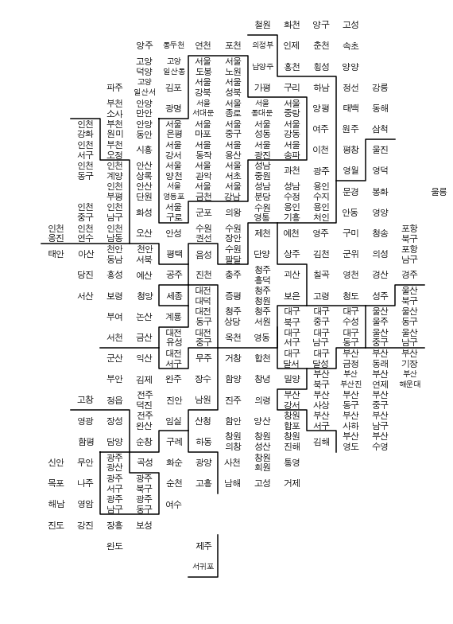

```python
plt.figure(figsize=(8, 11))

# 지역 이름 표시
for idx, row in draw_korea.iterrows():

    # 광역시는 구 이름이 겹치는 경우가 많아서 시단위 이름도 같이 표시한다.
    # (중구, 서구)
    if len(row['ID'].split())==2:
        dispname = '{}\n{}'.format(row['ID'].split()[0], row['ID'].split()[1])
    elif row['ID'][:2]=='고성':
        dispname = '고성'
    else:
        dispname = row['ID']

    # 서대문구, 서귀포시 같이 이름이 3자 이상인 경우에 작은 글자로 표시한다.
    if len(dispname.splitlines()[-1]) >= 3:
        fontsize, linespacing = 9.5, 1.5
    else:
        fontsize, linespacing = 11, 1.2

    plt.annotate(dispname, (row['x']+0.5, row['y']+0.5), weight='bold',
                 fontsize=fontsize, ha='center', va='center',
                 linespacing=linespacing)

# 시도 경계 그린다.
for path in BORDER_LINES:
    ys, xs = zip(*path)
    plt.plot(xs, ys, c='black', lw=1.5)

plt.gca().invert_yaxis()
#plt.gca().set_aspect(1)

plt.axis('off')

plt.tight_layout()
plt.show()
```

- 인구에 대한 분석 결과인 pop과 지도를 그리기 위한 draw_korea의 대이터를 합칠 때 사용할 key인 ID 컬럼의 내용이 문제가 없는지 확인하자

```python
set(draw_korea['ID'].unique()) - set(pop['ID'].unique())
```

```
set()
```

```python
set(pop['ID'].unique()) - set(draw_korea['ID'].unique())
```

```
{'고양', '부천', '성남', '수원', '안산', '안양', '용인', '전주', '창원', '천안', '청주', '포항'}
```

- 위 결과에 따르면, pop에 행정구를 가진 시들의 데이터가 더 있다는 것을 알 수 있다.
- 어차피 지도에서는 표시되지 못하니 삭제한다.

```python
tmp_list = list(set(pop['ID'].unique()) - set(draw_korea['ID'].unique()))

for tmp in tmp_list:
    pop = pop.drop(pop[pop['ID']==tmp].index)

print(set(pop['ID'].unique()) - set(draw_korea['ID'].unique()))
```

```
set()
```

```python
pop.head()
```

|  | 광역시도 | 시도 | 20-39세여자 | 20-39세합계 | 65세이상합계 | 인구수남자 | 인구수여자 | 인구수합계 | 소멸비율 | 소멸위기지역 | ID |
| --- | --- | --- | --- | --- | --- | --- | --- | --- | --- | --- | --- |
| 0 | 강원도 | 강릉시 | 23098.0 | 49384.0 | 37679.0 | 106231.0 | 107615.0 | 213846.0 | 1.226041 | False | 강릉 |
| 1 | 강원도 | 고성군 | 2529.0 | 7023.0 | 7151.0 | 15899.0 | 14215.0 | 30114.0 | 0.707314 | True | 고성(강원) |
| 2 | 강원도 | 동해시 | 9753.0 | 21264.0 | 15124.0 | 47166.0 | 46131.0 | 93297.0 | 1.289738 | False | 동해 |
| 3 | 강원도 | 삼척시 | 7115.0 | 15823.0 | 14610.0 | 35253.0 | 34346.0 | 69599.0 | 0.973990 | True | 삼척 |
| 4 | 강원도 | 속초시 | 8752.0 | 18708.0 | 12752.0 | 40288.0 | 41505.0 | 81793.0 | 1.372647 | False | 속초 |

- 이제 pop과 draw_korea의 ID 컬럼이 일치했다고 보고, ID를 key로 merge를 시키도록 한다.

```python
pop = pd.merge(pop, draw_korea, how='left', on=['ID'])

pop.head()
```

|  | 광역시도 | 시도 | 20-39세여자 | 20-39세합계 | 65세이상합계 | 인구수남자 | 인구수여자 | 인구수합계 | 소멸비율 | 소멸위기지역 | ID | y | x |
| --- | --- | --- | --- | --- | --- | --- | --- | --- | --- | --- | --- | --- | --- |
| 0 | 강원도 | 강릉시 | 23098.0 | 49384.0 | 37679.0 | 106231.0 | 107615.0 | 213846.0 | 1.226041 | False | 강릉 | 3 | 11 |
| 1 | 강원도 | 고성군 | 2529.0 | 7023.0 | 7151.0 | 15899.0 | 14215.0 | 30114.0 | 0.707314 | True | 고성(강원) | 0 | 10 |
| 2 | 강원도 | 동해시 | 9753.0 | 21264.0 | 15124.0 | 47166.0 | 46131.0 | 93297.0 | 1.289738 | False | 동해 | 4 | 11 |
| 3 | 강원도 | 삼척시 | 7115.0 | 15823.0 | 14610.0 | 35253.0 | 34346.0 | 69599.0 | 0.973990 | True | 삼척 | 5 | 11 |
| 4 | 강원도 | 속초시 | 8752.0 | 18708.0 | 12752.0 | 40288.0 | 41505.0 | 81793.0 | 1.372647 | False | 속초 | 1 | 10 |

- 이제 위 pop 데이터에서 지도에 표현하고자 하는 데이터가 **인구수합계**라면 이 값들이 아까 만든 각 해당 행정구역에 위치하면 된다.

```python
mapdata = pop.pivot_table(index='y', columns='x', values='인구수합계')
masked_mapdata = np.ma.masked_where(np.isnan(mapdata), mapdata)
```

```python
mapdata
```

| x y | 0 | 1 | 2 | 3 | 4 | 5 | 6 | 7 | 8 | 9 | 10 | 11 | 12 | 13 |
| --- | --- | --- | --- | --- | --- | --- | --- | --- | --- | --- | --- | --- | --- | --- |
| 0 | NaN | NaN | NaN | NaN | NaN | NaN | NaN | 48013.0 | 26264.0 | 24010.0 | 30114.0 | NaN | NaN | NaN |
| 1 | NaN | NaN | NaN | 205513.0 | 98277.0 | 45907.0 | 154763.0 | 438457.0 | 32720.0 | 280707.0 | 81793.0 | NaN | NaN | NaN |
| 2 | NaN | NaN | NaN | 446233.0 | 292612.0 | 348220.0 | 567581.0 | 662154.0 | 70076.0 | 45991.0 | 27218.0 | NaN | NaN | NaN |
| 3 | NaN | NaN | 430781.000000 | 300839.0 | 363443.0 | 327195.0 | 450355.0 | 62448.0 | 193763.0 | 211101.0 | 38718.0 | 213846.0 | NaN | NaN |
| 4 | NaN | NaN | 283793.333333 | 252353.0 | 339484.0 | 314194.0 | 152737.0 | 355069.0 | 411005.0 | 111367.0 | 47070.0 | 93297.0 | NaN | NaN |
| 5 | NaN | 68010.0 | 283793.333333 | 345061.0 | 491476.0 | 379892.0 | 125249.0 | 299259.0 | 444168.0 | 111563.0 | 337979.0 | 69599.0 | NaN | NaN |
| 6 | NaN | 510733.0 | 283793.333333 | 402888.0 | 595485.0 | 400997.0 | 230241.0 | 357215.0 | 657831.0 | 210359.0 | 43318.0 | 51738.0 | NaN | NaN |
| 7 | NaN | 71014.0 | 330284.000000 | 375857.0 | 477739.0 | 506851.0 | 447192.0 | 237909.0 | 63778.0 | 327723.0 | 40073.0 | 39052.0 | NaN | NaN |
| 8 | NaN | NaN | 549716.000000 | 314002.0 | 370613.0 | 235386.0 | 567115.0 | 503830.0 | 232841.0 | 347833.0 | 74702.0 | 33539.0 | NaN | 10001.0 |
| 9 | NaN | 115249.0 | 417103.000000 | 640890.0 | 417551.0 | 284890.0 | 156763.0 | 340654.0 | 417163.0 | 226130.0 | 168798.0 | 17713.0 | NaN | NaN |
| 10 | 21351.0 | 328627.0 | 530982.000000 | 208656.0 | 182896.0 | 358393.0 | 296479.0 | 136517.0 | 46166.0 | 109247.0 | 419891.0 | 26301.0 | 272027.0 | NaN |
| 11 | 63900.0 | 302929.0 | 258919.000000 | 359036.0 | 470832.0 | 97787.0 | 198515.0 | 30503.0 | 101799.0 | 142256.0 | 24171.0 | 54014.0 | 244748.0 | NaN |
| 12 | NaN | 166630.0 | 99971.000000 | 81339.0 | 109931.0 | 69950.0 | 208350.0 | 253563.0 | 38973.0 | 123199.0 | 100521.0 | 258037.0 | 259452.0 | NaN |
| 13 | NaN | 170788.0 | 103873.000000 | 32753.0 | 243048.0 | 192688.0 | 37308.0 | 190813.0 | 34221.0 | 34257.0 | 43564.0 | 45205.0 | 195285.0 | NaN |
| 14 | NaN | NaN | 70187.000000 | 123213.0 | 42634.0 | 234959.0 | 173701.0 | 217120.0 | 440383.0 | 79712.0 | 447011.0 | 219255.0 | 174514.0 | NaN |
| 15 | NaN | NaN | 56012.000000 | 54612.0 | 343222.0 | 252490.0 | 52267.0 | 50552.0 | 199507.0 | 156433.0 | 351352.0 | 242536.0 | 340714.0 | NaN |
| 16 | NaN | NaN | 277551.000000 | 300479.0 | 491011.0 | 24949.0 | 63308.0 | 48026.0 | 591891.0 | 218268.0 | 244624.0 | 272745.0 | 158527.0 | NaN |
| 17 | NaN | NaN | 57005.000000 | 87782.0 | 95480.0 | 23628.0 | 40241.0 | 63982.0 | 108354.0 | 310202.0 | 376526.0 | 207268.0 | 419853.0 | NaN |
| 18 | NaN | 60597.0 | 115173.000000 | 289899.0 | 26069.0 | 84188.0 | 346739.0 | 28111.0 | 108909.0 | 232800.0 | 89826.0 | 45208.0 | NaN | NaN |
| 19 | NaN | 55618.0 | 46104.000000 | 361845.0 | 30197.0 | 36098.0 | 68937.0 | 317037.0 | 181797.0 | 112973.0 | 334603.0 | 278779.0 | NaN | NaN |
| 20 | NaN | 34397.0 | 47229.000000 | 29949.0 | 27412.0 | 49622.0 | 252435.0 | 231571.0 | 187313.0 | 529422.0 | 126362.0 | 179324.0 | NaN | NaN |
| 21 | 42652.0 | 82109.0 | 403049.000000 | 30400.0 | 65303.0 | 155580.0 | 114912.0 | 210791.0 | 138160.0 | NaN | NaN | NaN | NaN | NaN |
| 22 | 237739.0 | 104376.0 | 309579.000000 | 441066.0 | 278548.0 | 67656.0 | 45129.0 | 54703.0 | 257183.0 | NaN | NaN | NaN | NaN | NaN |
| 23 | 75121.0 | 57045.0 | 219729.000000 | 95791.0 | 288988.0 | NaN | NaN | NaN | NaN | NaN | NaN | NaN | NaN | NaN |
| 24 | 32078.0 | 37753.0 | 40669.000000 | 44469.0 | NaN | NaN | NaN | NaN | NaN | NaN | NaN | NaN | NaN | NaN |
| 25 | NaN | NaN | 52668.000000 | NaN | NaN | 470665.0 | NaN | NaN | NaN | NaN | NaN | NaN | NaN | NaN |
| 26 | NaN | NaN | NaN | NaN | NaN | 170932.0 | NaN | NaN | NaN | NaN | NaN | NaN | NaN | NaN |

```python
masked_mapdata
```

```
masked_array(
  data=[[--, --, --, --, --, --, --, 48013.0, 26264.0, 24010.0, 30114.0,
         --, --, --],
        [--, --, --, 205513.0, 98277.0, 45907.0, 154763.0, 438457.0,
         32720.0, 280707.0, 81793.0, --, --, --],
        [--, --, --, 446233.0, 292612.0, 348220.0, 567581.0, 662154.0,
         70076.0, 45991.0, 27218.0, --, --, --],
        [--, --, 430781.0, 300839.0, 363443.0, 327195.0, 450355.0,
         62448.0, 193763.0, 211101.0, 38718.0, 213846.0, --, --],
        [--, --, 283793.3333333333, 252353.0, 339484.0, 314194.0,
         152737.0, 355069.0, 411005.0, 111367.0, 47070.0, 93297.0, --,
         --],
        [--, 68010.0, 283793.3333333333, 345061.0, 491476.0, 379892.0,
         125249.0, 299259.0, 444168.0, 111563.0, 337979.0, 69599.0, --,
         --],
        [--, 510733.0, 283793.3333333333, 402888.0, 595485.0, 400997.0,
         230241.0, 357215.0, 657831.0, 210359.0, 43318.0, 51738.0, --,
         --],
        [--, 71014.0, 330284.0, 375857.0, 477739.0, 506851.0, 447192.0,
         237909.0, 63778.0, 327723.0, 40073.0, 39052.0, --, --],
        [--, --, 549716.0, 314002.0, 370613.0, 235386.0, 567115.0,
         503830.0, 232841.0, 347833.0, 74702.0, 33539.0, --, 10001.0],
        [--, 115249.0, 417103.0, 640890.0, 417551.0, 284890.0, 156763.0,
         340654.0, 417163.0, 226130.0, 168798.0, 17713.0, --, --],
        [21351.0, 328627.0, 530982.0, 208656.0, 182896.0, 358393.0,
         296479.0, 136517.0, 46166.0, 109247.0, 419891.0, 26301.0,
         272027.0, --],
        [63900.0, 302929.0, 258919.0, 359036.0, 470832.0, 97787.0,
         198515.0, 30503.0, 101799.0, 142256.0, 24171.0, 54014.0,
         244748.0, --],
        [--, 166630.0, 99971.0, 81339.0, 109931.0, 69950.0, 208350.0,
         253563.0, 38973.0, 123199.0, 100521.0, 258037.0, 259452.0, --],
        [--, 170788.0, 103873.0, 32753.0, 243048.0, 192688.0, 37308.0,
         190813.0, 34221.0, 34257.0, 43564.0, 45205.0, 195285.0, --],
        [--, --, 70187.0, 123213.0, 42634.0, 234959.0, 173701.0,
         217120.0, 440383.0, 79712.0, 447011.0, 219255.0, 174514.0, --],
        [--, --, 56012.0, 54612.0, 343222.0, 252490.0, 52267.0, 50552.0,
         199507.0, 156433.0, 351352.0, 242536.0, 340714.0, --],
        [--, --, 277551.0, 300479.0, 491011.0, 24949.0, 63308.0, 48026.0,
         591891.0, 218268.0, 244624.0, 272745.0, 158527.0, --],
```

[output cut: 59 more lines]

```
        [ True, False, False, False, False, False, False, False, False,
         False, False, False,  True,  True],
        [False, False, False, False, False, False, False, False, False,
          True,  True,  True,  True,  True],
        [False, False, False, False, False, False, False, False, False,
          True,  True,  True,  True,  True],
        [False, False, False, False, False,  True,  True,  True,  True,
          True,  True,  True,  True,  True],
        [False, False, False, False,  True,  True,  True,  True,  True,
          True,  True,  True,  True,  True],
        [ True,  True, False,  True,  True, False,  True,  True,  True,
          True,  True,  True,  True,  True],
        [ True,  True,  True,  True,  True, False,  True,  True,  True,
          True,  True,  True,  True,  True]],
  fill_value=1e+20)
```

- 위 내용과 colormap을 완성하는 명령을 추가해서 함수로 만들자

```python
def drawKorea(targetData, blockedMap, cmapname):
    gamma = 0.75

    whitelabelmin = (max(blockedMap[targetData]) -
                                     min(blockedMap[targetData]))*0.25 + \
                                                                min(blockedMap[targetData])

    datalabel = targetData

    vmin = min(blockedMap[targetData])
    vmax = max(blockedMap[targetData])

    mapdata = blockedMap.pivot_table(index='y', columns='x', values=targetData)
    masked_mapdata = np.ma.masked_where(np.isnan(mapdata), mapdata)

    plt.figure(figsize=(9, 11))
    plt.pcolor(masked_mapdata, vmin=vmin, vmax=vmax, cmap=cmapname,
               edgecolor='#aaaaaa', linewidth=0.5)

    # 지역 이름 표시
    for idx, row in blockedMap.iterrows():
        # 광역시는 구 이름이 겹치는 경우가 많아서 시단위 이름도 같이 표시한다.
        #(중구, 서구)
        if len(row['ID'].split())==2:
            dispname = '{}\n{}'.format(row['ID'].split()[0], row['ID'].split()[1])
        elif row['ID'][:2]=='고성':
            dispname = '고성'
        else:
            dispname = row['ID']

        # 서대문구, 서귀포시 같이 이름이 3자 이상인 경우에 작은 글자로 표시한다.
        if len(dispname.splitlines()[-1]) >= 3:
            fontsize, linespacing = 10.0, 1.1
        else:
            fontsize, linespacing = 11, 1.

        annocolor = 'white' if row[targetData] > whitelabelmin else 'black'
        plt.annotate(dispname, (row['x']+0.5, row['y']+0.5), weight='bold',
                     fontsize=fontsize, ha='center', va='center', color=annocolor,
                     linespacing=linespacing)

    # 시도 경계 그린다.
    for path in BORDER_LINES:
        ys, xs = zip(*path)
        plt.plot(xs, ys, c='black', lw=2)

    plt.gca().invert_yaxis()

    plt.axis('off')

    cb = plt.colorbar(shrink=.1, aspect=10)
    cb.set_label(datalabel)

    plt.tight_layout()
    plt.show()
```

## 5-7 인구 현황 및 인구 소멸 지역 확인하기

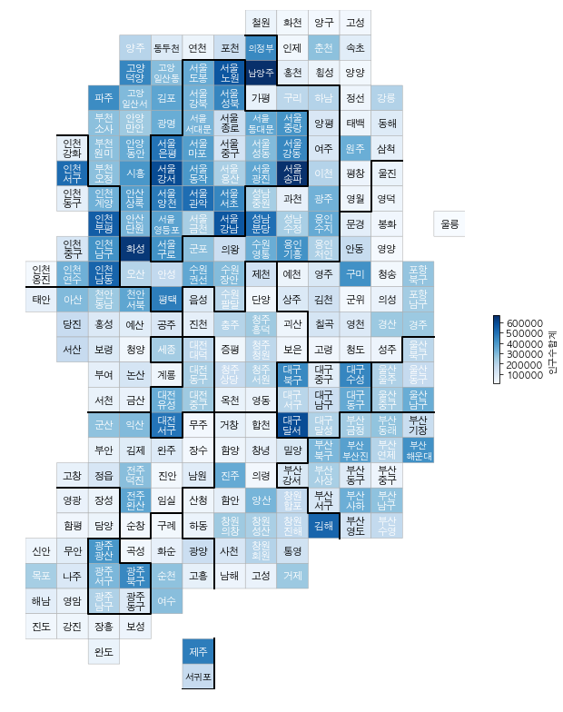

```python
drawKorea('인구수합계', pop, 'Blues')
```

- 인구 소멸 위기 지역에 대한 표현

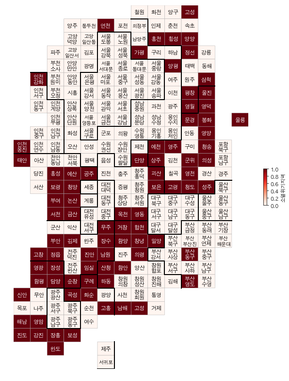

```python
pop['소멸위기지역'] = [1 if con else 0 for con in pop['소멸위기지역']]
drawKorea('소멸위기지역', pop, 'Reds')
```

## 5-8. 인구 현황에서 여성 인구 비율 확인하기

```python
def drawKorea(targetData, blockedMap, cmapname):
    gamma = 0.75

    whitelabelmin = 20.

    datalabel = targetData

    tmp_max = max([ np.abs(min(blockedMap[targetData])),
                                  np.abs(max(blockedMap[targetData]))])
    vmin, vmax = -tmp_max, tmp_max

    mapdata = blockedMap.pivot_table(index='y', columns='x', values=targetData)
    masked_mapdata = np.ma.masked_where(np.isnan(mapdata), mapdata)

    plt.figure(figsize=(9, 11))
    plt.pcolor(masked_mapdata, vmin=vmin, vmax=vmax, cmap=cmapname,
               edgecolor='#aaaaaa', linewidth=0.5)

    # 지역 이름 표시
    for idx, row in blockedMap.iterrows():
        # 광역시는 구 이름이 겹치는 경우가 많아서 시단위 이름도 같이 표시한다.
        #(중구, 서구)
        if len(row['ID'].split())==2:
            dispname = '{}\n{}'.format(row['ID'].split()[0], row['ID'].split()[1])
        elif row['ID'][:2]=='고성':
            dispname = '고성'
        else:
            dispname = row['ID']

        # 서대문구, 서귀포시 같이 이름이 3자 이상인 경우에 작은 글자로 표시한다.
        if len(dispname.splitlines()[-1]) >= 3:
            fontsize, linespacing = 10.0, 1.1
        else:
            fontsize, linespacing = 11, 1.

        annocolor = 'white' if np.abs(row[targetData]) > whitelabelmin else 'black'
        plt.annotate(dispname, (row['x']+0.5, row['y']+0.5), weight='bold',
                     fontsize=fontsize, ha='center', va='center', color=annocolor,
                     linespacing=linespacing)

    # 시도 경계 그린다.
    for path in BORDER_LINES:
        ys, xs = zip(*path)
        plt.plot(xs, ys, c='black', lw=2)

    plt.gca().invert_yaxis()

    plt.axis('off')

    cb = plt.colorbar(shrink=.1, aspect=10)
    cb.set_label(datalabel)

    plt.tight_layout()
    plt.show()
```

```python
pop.head()
```

|  | 광역시도 | 시도 | 20-39세여자 | 20-39세합계 | 65세이상합계 | 인구수남자 | 인구수여자 | 인구수합계 | 소멸비율 | 소멸위기지역 | ID | y | x |
| --- | --- | --- | --- | --- | --- | --- | --- | --- | --- | --- | --- | --- | --- |
| 0 | 강원도 | 강릉시 | 23098.0 | 49384.0 | 37679.0 | 106231.0 | 107615.0 | 213846.0 | 1.226041 | 0 | 강릉 | 3 | 11 |
| 1 | 강원도 | 고성군 | 2529.0 | 7023.0 | 7151.0 | 15899.0 | 14215.0 | 30114.0 | 0.707314 | 1 | 고성(강원) | 0 | 10 |
| 2 | 강원도 | 동해시 | 9753.0 | 21264.0 | 15124.0 | 47166.0 | 46131.0 | 93297.0 | 1.289738 | 0 | 동해 | 4 | 11 |
| 3 | 강원도 | 삼척시 | 7115.0 | 15823.0 | 14610.0 | 35253.0 | 34346.0 | 69599.0 | 0.973990 | 1 | 삼척 | 5 | 11 |
| 4 | 강원도 | 속초시 | 8752.0 | 18708.0 | 12752.0 | 40288.0 | 41505.0 | 81793.0 | 1.372647 | 0 | 속초 | 1 | 10 |

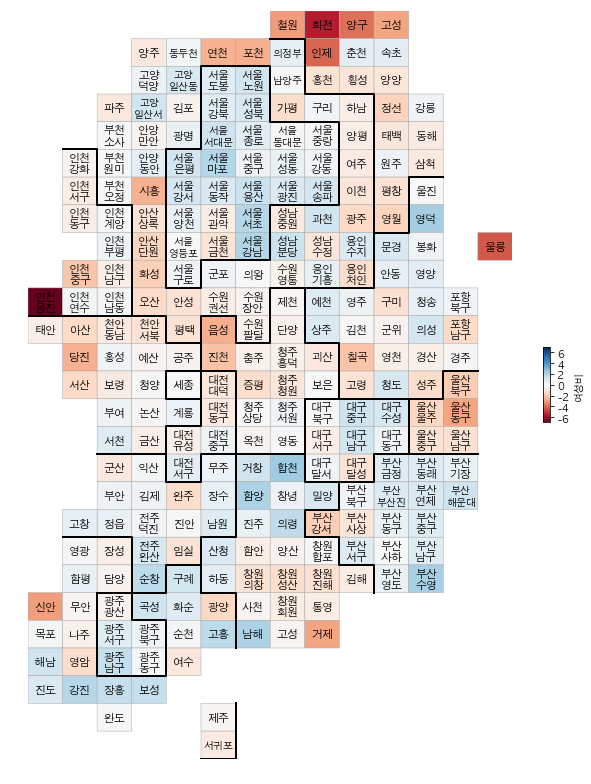

```python
pop['여성비'] = (pop['인구수여자']/pop['인구수합계'] - 0.5)*100
drawKorea('여성비', pop, 'RdBu')
```

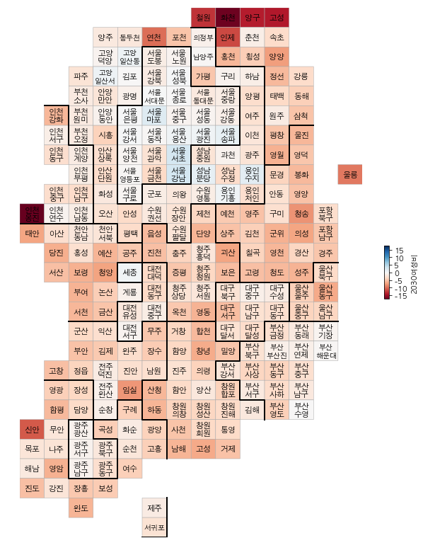

```python
pop['2030여성비'] = (pop['20-39세여자']/pop['20-39세합계'] - 0.5)*100
drawKorea('2030여성비', pop, 'RdBu')
```

## 5-9. Folium에서 인구 소멸 위기 지역 표현하기

```python
pop_folium = pop.set_index('ID')
pop_folium.head()
```

| ID | 광역시도 | 시도 | 20-39세여자 | 20-39세합계 | 65세이상합계 | 인구수남자 | 인구수여자 | 인구수합계 | 소멸비율 | 소멸위기지역 | y | x | 여성비 | 2030여성비 |
| --- | --- | --- | --- | --- | --- | --- | --- | --- | --- | --- | --- | --- | --- | --- |
| 강릉 | 강원도 | 강릉시 | 23098.0 | 49384.0 | 37679.0 | 106231.0 | 107615.0 | 213846.0 | 1.226041 | 0 | 3 | 11 | 0.323597 | -3.227766 |
| 고성(강원) | 강원도 | 고성군 | 2529.0 | 7023.0 | 7151.0 | 15899.0 | 14215.0 | 30114.0 | 0.707314 | 1 | 0 | 10 | -2.796042 | -13.989748 |
| 동해 | 강원도 | 동해시 | 9753.0 | 21264.0 | 15124.0 | 47166.0 | 46131.0 | 93297.0 | 1.289738 | 0 | 4 | 11 | -0.554680 | -4.133747 |
| 삼척 | 강원도 | 삼척시 | 7115.0 | 15823.0 | 14610.0 | 35253.0 | 34346.0 | 69599.0 | 0.973990 | 1 | 5 | 11 | -0.651590 | -5.033812 |
| 속초 | 강원도 | 속초시 | 8752.0 | 18708.0 | 12752.0 | 40288.0 | 41505.0 | 81793.0 | 1.372647 | 0 | 1 | 10 | 0.743951 | -3.217875 |

```python
import folium
import json
import warnings
warnings.simplefilter(action='ignore', category=FutureWarning)
```

```python
geo_path = '../data/05. skorea_municipalities_geo_simple.json'
geo_str = json.load(open(geo_path, encoding='utf-8'))

map = folium.Map(location=[36.2002, 127.054], zoom_start=7)
map.choropleth(geo_data = geo_str,
               data = pop_folium['인구수합계'],
               columns = [pop_folium.index, pop_folium['인구수합계']],
               fill_color = 'YlGnBu', #PuRd, YlGnBu
               key_on = 'feature.id')

map
```

[interactive chart not shown]

```python
map = folium.Map(location=[36.2002, 127.054], zoom_start=7)
map.choropleth(geo_data = geo_str,
               data = pop_folium['소멸위기지역'],
               columns = [pop_folium.index, pop_folium['소멸위기지역']],
               fill_color = 'PuRd', #PuRd, YlGnBu
               key_on = 'feature.id')

map
```

[interactive chart not shown]

```python
draw_korea.to_csv("../data/05. draw_korea.csv", encoding='utf-8', sep=',')
```